# Data Camp Insights

### *Foundations of Inference*

Chapter 1 - Introduction to Ideas of Inference

Statistical inference is the process of making claims about a population based on information from a sample of data:

- General first step is to assume similarity (null hypothesis is of no differences - “claim that is not interesting” - Ho)
- The research hypothesis is the alternate hypothesis, also known as Ha
- The typical goal is to disprove the null hypothesis

Randomized distributions:

- Take the difference in a single key metric from two samples
- Can generate a distribution of differences assuming that the null hypothesis is true
- Take the overall data collected across both samples
  - Randomly permute the data to get a null distribution
  - Need sufficient permutations to get an appropriate density function for the null hypothesis

Using the randomization distribution - comparing the observed statistic to the null distribution:

- Goal is to show that our observed data are different than the null hypothesis
- How much of the null hypothesis distribution is “more extreme” than the observed data?

The sample being consistent with the null hypothesis does not “prove” the null hypothesis; you can only “reject” the null hypothesis

Example code includes:

```r
# PROBLEM - I DO NOT HAVE oilabs::rep_sample_n() ; cut/paste to replicate as oilabs_rep_sample_n
# Copied code from https://github.com/OpenIntroOrg/oilabs/blob/master/R/rep_sample_n.R
oilabs_rep_sample_n <- function(tbl, size, replace = FALSE, reps = 1) {
    n <- nrow(tbl)
    i <- unlist(replicate(reps, sample.int(n, size, replace = replace), simplify = FALSE))
    rep_tbl <- cbind(replicate = rep(1:reps,rep(size,reps)), tbl[i,])
    dplyr::group_by(rep_tbl, replicate)
}
```

And, then the actual coding:

```r
data(NHANES, package="NHANES")

# What are the variables in the NHANES dataset?
names(NHANES)
```

```
##  [1] "ID"               "SurveyYr"         "Gender"
##  [4] "Age"              "AgeDecade"        "AgeMonths"
##  [7] "Race1"            "Race3"            "Education"
## [10] "MaritalStatus"    "HHIncome"         "HHIncomeMid"
## [13] "Poverty"          "HomeRooms"        "HomeOwn"
## [16] "Work"             "Weight"           "Length"
## [19] "HeadCirc"         "Height"           "BMI"
## [22] "BMICatUnder20yrs" "BMI_WHO"          "Pulse"
## [25] "BPSysAve"         "BPDiaAve"         "BPSys1"
## [28] "BPDia1"           "BPSys2"           "BPDia2"
## [31] "BPSys3"           "BPDia3"           "Testosterone"
## [34] "DirectChol"       "TotChol"          "UrineVol1"
## [37] "UrineFlow1"       "UrineVol2"        "UrineFlow2"
## [40] "Diabetes"         "DiabetesAge"      "HealthGen"
## [43] "DaysPhysHlthBad"  "DaysMentHlthBad"  "LittleInterest"
## [46] "Depressed"        "nPregnancies"     "nBabies"
## [49] "Age1stBaby"       "SleepHrsNight"    "SleepTrouble"
## [52] "PhysActive"       "PhysActiveDays"   "TVHrsDay"
## [55] "CompHrsDay"       "TVHrsDayChild"    "CompHrsDayChild"
## [58] "Alcohol12PlusYr"  "AlcoholDay"       "AlcoholYear"
## [61] "SmokeNow"         "Smoke100"         "Smoke100n"
## [64] "SmokeAge"         "Marijuana"        "AgeFirstMarij"
## [67] "RegularMarij"     "AgeRegMarij"      "HardDrugs"
## [70] "SexEver"          "SexAge"           "SexNumPartnLife"
## [73] "SexNumPartYear"   "SameSex"          "SexOrientation"
## [76] "PregnantNow"
```

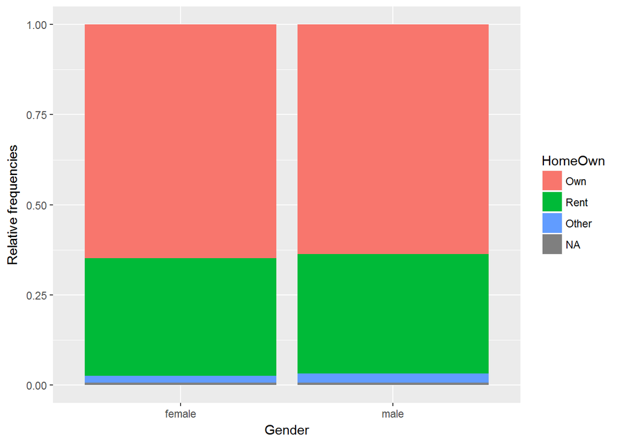

```r
# Create bar plot for Home Ownership by Gender
ggplot(NHANES, aes(x = Gender, fill = HomeOwn)) +
  geom_bar(position = "fill") +
  ylab("Relative frequencies")
```

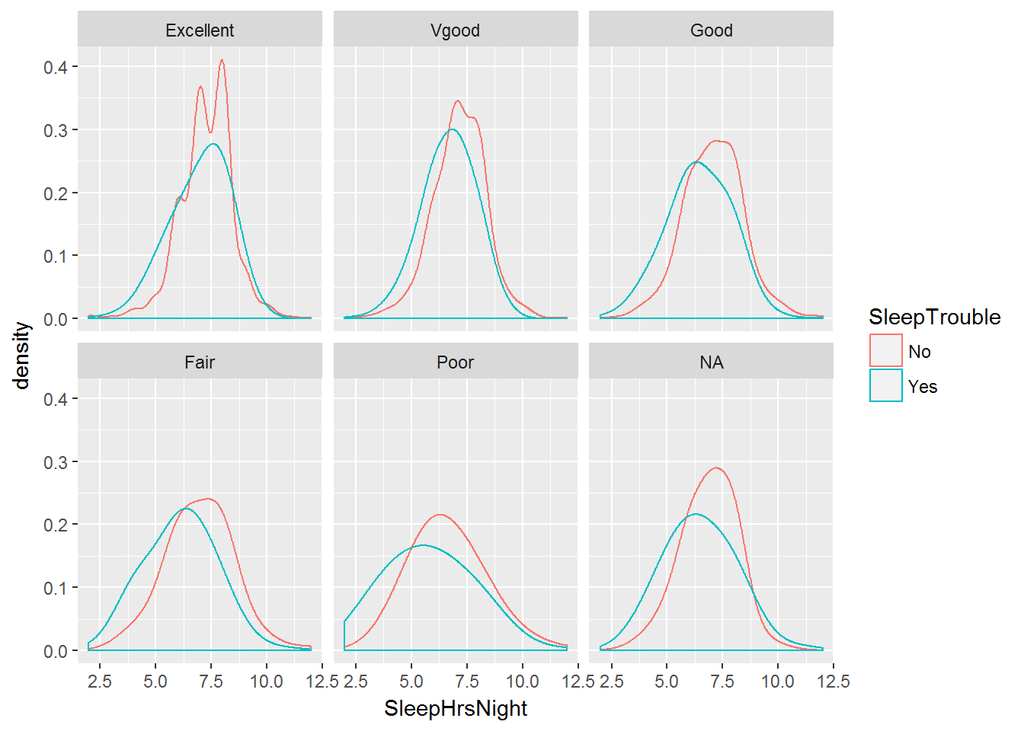

```r
# Density for SleepHrsNight colored by SleepTrouble, faceted by HealthGen
ggplot(NHANES, aes(x = SleepHrsNight, col = SleepTrouble)) +
  geom_density(adjust = 2) +
  facet_wrap(~ HealthGen)
```

```r
# Subset the data: homes
homes <- NHANES %>%
  select(Gender, HomeOwn) %>%
  filter(HomeOwn %in% c("Own", "Rent"))

# Perform one permutation
homes %>%
  mutate(HomeOwn_perm = sample(HomeOwn)) %>%
  group_by(Gender) %>%
  summarize(prop_own_perm = mean(HomeOwn_perm == "Own"),
            prop_own = mean(HomeOwn == "Own")) %>%
  summarize(diff_perm = diff(prop_own_perm),
            diff_orig = diff(prop_own))
```

```
## # A tibble: 1 × 2
##     diff_perm    diff_orig
##         <dbl>        <dbl>
## 1 0.001644559 -0.007828723
```

```r
# Perform 10 permutations
homeown_perm <- homes %>%
  oilabs_rep_sample_n(size = nrow(homes), reps = 10) %>%
  mutate(HomeOwn_perm = sample(HomeOwn)) %>%
  group_by(replicate, Gender) %>%
  summarize(prop_own_perm = mean(HomeOwn_perm == "Own"),
            prop_own = mean(HomeOwn == "Own")) %>%
  summarize(diff_perm = diff(prop_own_perm),
            diff_orig = diff(prop_own)) # male - female

# Print differences to console
homeown_perm
```

```
## # A tibble: 10 × 3
##    replicate    diff_perm    diff_orig
##        <int>        <dbl>        <dbl>
## 1          1 -0.007416841 -0.007828723
## 2          2  0.023886176 -0.007828723
## 3          3 -0.005769314 -0.007828723
## 4          4  0.004939613 -0.007828723
## 5          5  0.005351495 -0.007828723
## 6          6 -0.008240605 -0.007828723
## 7          7 -0.006593078 -0.007828723
## 8          8 -0.001238614 -0.007828723
## 9          9 -0.020185177 -0.007828723
## 10        10  0.007822786 -0.007828723
```

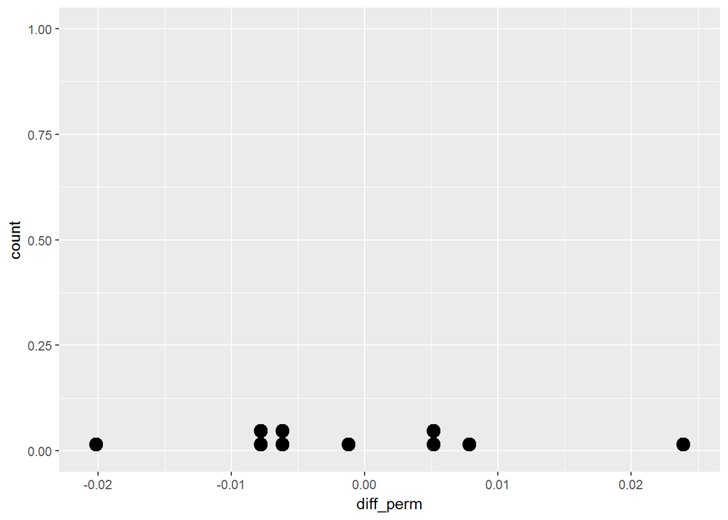

```r
# Dotplot of 10 permuted differences in proportions
ggplot(homeown_perm, aes(x = diff_perm)) +
  geom_dotplot(binwidth = 0.001)
```

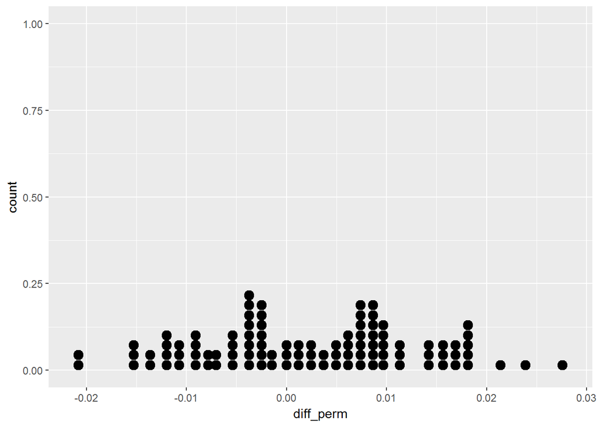

```r
# Perform 100 permutations
homeown_perm <- homes %>%
  oilabs_rep_sample_n(nrow(homes), reps=100) %>%
  mutate(HomeOwn_perm = sample(HomeOwn)) %>%
  group_by(replicate, Gender) %>%
  summarize(prop_own_perm = mean(HomeOwn_perm == "Own"),
            prop_own = mean(HomeOwn == "Own")) %>%
  summarize(diff_perm = diff(prop_own_perm),
            diff_orig = diff(prop_own)) # male - female

# Dotplot of 100 permuted differences in proportions
ggplot(homeown_perm, aes(x = diff_perm)) +
  geom_dotplot(binwidth = 0.001)
```

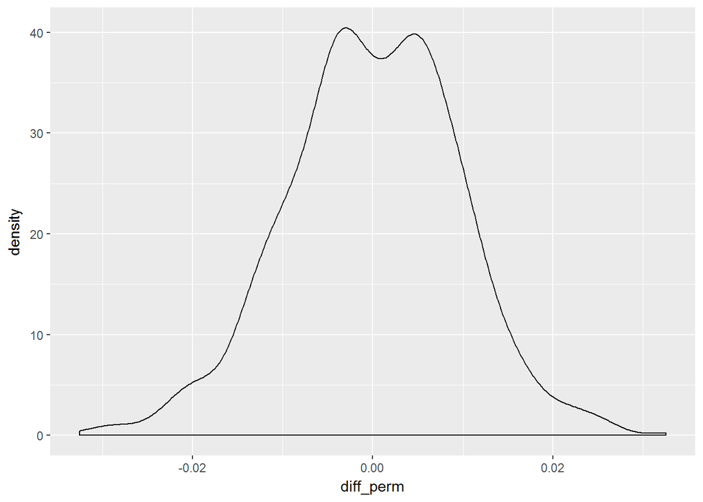

```r
# Perform 1000 permutations
homeown_perm <- homes %>%
  oilabs_rep_sample_n(nrow(homes), reps=1000) %>%
  mutate(HomeOwn_perm = sample(HomeOwn)) %>%
  group_by(replicate, Gender) %>%
  summarize(prop_own_perm = mean(HomeOwn_perm == "Own"),
            prop_own = mean(HomeOwn == "Own")) %>%
  summarize(diff_perm = diff(prop_own_perm),
            diff_orig = diff(prop_own)) # male - female


# Density plot of 1000 permuted differences in proportions
ggplot(homeown_perm, aes(x = diff_perm)) +
  geom_density()
```

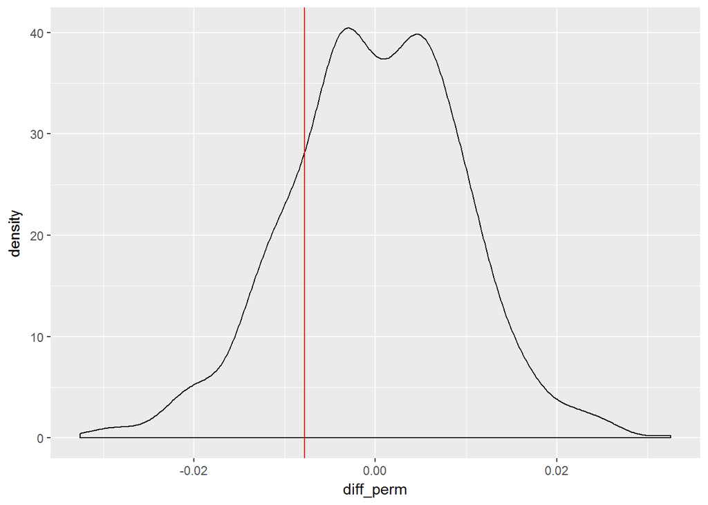

```r
# Plot permuted differences
ggplot(homeown_perm, aes(x = diff_perm)) +
  geom_density() +
  geom_vline(aes(xintercept = diff_orig),
          col = "red")
```

```r
# Compare permuted differences to observed difference
homeown_perm %>%
  summarize(sum(diff_orig >= diff_perm))
```

```
## # A tibble: 1 × 1
##   `sum(diff_orig >= diff_perm)`
##                           <int>
## 1                           208
```

Chapter 2 - Completing a randomization study

Gender discrimination case - promotion case study among bank managers:

- Identical files, only difference is gender, assess number promoted to next level
- The shuffling process breaks the link between gender and promotion - understand the null distribution

Distribution of statistics - different forms of the null hypothesis:

- Difference in proportions (subtract) - used in this course
- Ratio of proportions (divide) - used in other courses
- Can get the quantiles in R using quantile(x, p=)
- The critical region is the (often pre-defined) region where the observed statistic will be deemed much different than the null distribution

Why 0.05 for the critical region?

- “The choice is somewhat arbitrary, but use is historical, ingrained in science, and somewhat intuitive”
  - RA Fisher (1929) indicated that significance of 0.05 should indicate what to throw away, not what to believe
- Statistical significance can be thought of as the “degree of skepticism”
  - Only “significant results” should lead to further investigation

What is a p-value?

- The level of significance would mean that we sometimes reject the null hypothesis, and sometimes do not
- The p-value is the probability of observing data as/more extreme as what we got assuming the null hypothesis were true

Example code includes:

```r
discPromote <- "promoted ; promoted ; promoted ; promoted ; promoted ; promoted ; promoted ; promoted ; promoted ; promoted ; promoted ; promoted ; promoted ; promoted ; promoted ; promoted ; promoted ; promoted ; promoted ; promoted ; promoted ; promoted ; promoted ; promoted ; promoted ; promoted ; promoted ; promoted ; promoted ; promoted ; promoted ; promoted ; promoted ; promoted ; promoted ; not_promoted ; not_promoted ; not_promoted ; not_promoted ; not_promoted ; not_promoted ; not_promoted ; not_promoted ; not_promoted ; not_promoted ; not_promoted ; not_promoted ; not_promoted"
discSex <- "male ; male ; male ; male ; male ; male ; male ; male ; male ; male ; male ; male ; male ; male ; male ; male ; male ; male ; male ; male ; male ; female ; female ; female ; female ; female ; female ; female ; female ; female ; female ; female ; female ; female ; female ; male ; male ; male ; female ; female ; female ; female ; female ; female ; female ; female ; female ; female"

disc <- data.frame(promote=factor(strsplit(discPromote, " ; ")[[1]],
                                  levels=c("not_promoted", "promoted")
                                  ),
                   sex=factor(strsplit(discSex, " ; ")[[1]])
                   )

# Create a contingency table summarizing the data
table(disc$sex, disc$promote)
```

```
##
##          not_promoted promoted
##   female           10       14
##   male              3       21
```

```r
# Find proportion of each sex who were promoted
disc %>%
  group_by(sex) %>%
  summarize(promoted_prop=mean(promote == "promoted"))
```

```
## # A tibble: 2 × 2
##      sex promoted_prop
##   <fctr>         <dbl>
## 1 female     0.5833333
## 2   male     0.8750000
```

```r
# Sample the entire data frame 5 times
disc %>%
  oilabs_rep_sample_n(size = nrow(disc), reps = 5)
```

```
## Source: local data frame [240 x 3]
## Groups: replicate [5]
##
##    replicate      promote    sex
## *      <int>       <fctr> <fctr>
## 1          1     promoted   male
## 2          1     promoted female
## 3          1     promoted   male
## 4          1     promoted female
## 5          1     promoted female
## 6          1     promoted female
## 7          1 not_promoted   male
## 8          1 not_promoted female
## 9          1     promoted   male
## 10         1 not_promoted female
## # ... with 230 more rows
```

```r
# Shuffle the promote variable within replicate
disc %>%
  oilabs_rep_sample_n(size = nrow(disc), reps = 5) %>%
  mutate(prom_perm = sample(promote))
```

```
## Source: local data frame [240 x 4]
## Groups: replicate [5]
##
##    replicate      promote    sex    prom_perm
##        <int>       <fctr> <fctr>       <fctr>
## 1          1     promoted female     promoted
## 2          1     promoted   male not_promoted
## 3          1     promoted female     promoted
## 4          1 not_promoted female     promoted
## 5          1     promoted female     promoted
## 6          1     promoted   male     promoted
## 7          1     promoted   male     promoted
## 8          1     promoted female     promoted
## 9          1     promoted   male not_promoted
## 10         1     promoted   male     promoted
## # ... with 230 more rows
```

```r
# Find the proportion of promoted in each replicate and sex
disc %>%
  oilabs_rep_sample_n(size = nrow(disc), reps = 5) %>%
  mutate(prom_perm = sample(promote)) %>%
  group_by(replicate, sex) %>%
  summarize(prop_prom_perm = mean(prom_perm == "promoted"),
            prop_prom = mean(promote == "promoted"))
```

```
## Source: local data frame [10 x 4]
## Groups: replicate [?]
##
##    replicate    sex prop_prom_perm prop_prom
##        <int> <fctr>          <dbl>     <dbl>
## 1          1 female      0.7916667 0.5833333
## 2          1   male      0.6666667 0.8750000
## 3          2 female      0.6666667 0.5833333
## 4          2   male      0.7916667 0.8750000
## 5          3 female      0.6250000 0.5833333
## 6          3   male      0.8333333 0.8750000
## 7          4 female      0.6666667 0.5833333
## 8          4   male      0.7916667 0.8750000
## 9          5 female      0.7916667 0.5833333
## 10         5   male      0.6666667 0.8750000
```

```r
# Difference in proportion of promoted across sex grouped by gender
disc %>%
  oilabs_rep_sample_n(size = nrow(disc), reps = 5) %>%
  mutate(prom_perm = sample(promote)) %>%
  group_by(replicate, sex) %>%
  summarize(prop_prom_perm = mean(prom_perm == "promoted"),
            prop_prom = mean(promote == "promoted"))  %>%
  summarize(diff_perm = diff(prop_prom_perm),
            diff_orig = diff(prop_prom))  # male - female
```

```
## # A tibble: 5 × 3
##   replicate   diff_perm diff_orig
##       <int>       <dbl>     <dbl>
## 1         1  0.12500000 0.2916667
## 2         2 -0.04166667 0.2916667
## 3         3 -0.20833333 0.2916667
## 4         4 -0.04166667 0.2916667
## 5         5  0.29166667 0.2916667
```

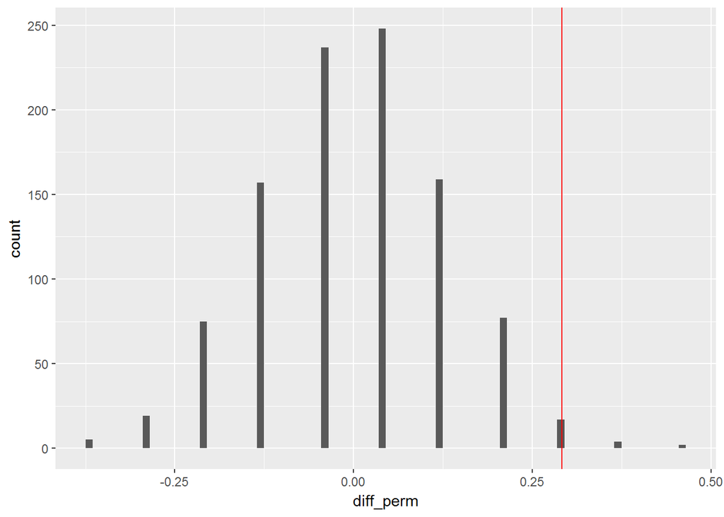

```r
# Create a data frame of differences in promotion rates
disc_perm <- disc %>%
  oilabs_rep_sample_n(size = nrow(disc), reps = 1000) %>%
  mutate(prom_perm = sample(promote)) %>%
  group_by(replicate, sex) %>%
  summarize(prop_prom_perm = mean(prom_perm == "promoted"),
            prop_prom = mean(promote == "promoted")) %>%
  summarize(diff_perm = diff(prop_prom_perm),
            diff_orig = diff(prop_prom))  # male - female

# Histogram of permuted differences
ggplot(disc_perm, aes(x = diff_perm)) +
  geom_histogram(binwidth = 0.01) +
  geom_vline(aes(xintercept = diff_orig), col = "red")
```

```r
# Find the 0.90, 0.95, and 0.99 quantiles of diff_perm
disc_perm %>%
  summarize(q.90 = quantile(diff_perm, p = 0.90),
            q.95 = quantile(diff_perm, p = 0.95),
            q.99 = quantile(diff_perm, p = 0.99)
            )
```

```
## # A tibble: 1 × 3
##        q.90      q.95      q.99
##       <dbl>     <dbl>     <dbl>
## 1 0.1333333 0.2083333 0.2916667
```

```r
# Find the 0.10, 0.05, and 0.01 quantiles of diff_perm
disc_perm %>%
  summarize(q.01 = quantile(diff_perm, p = 0.01),
            q.05 = quantile(diff_perm, p = 0.05),
            q.10 = quantile(diff_perm, p = 0.10)
            )
```

```
## # A tibble: 1 × 3
##         q.01       q.05   q.10
##        <dbl>      <dbl>  <dbl>
## 1 -0.2916667 -0.2083333 -0.125
```

```r
discsmallSex <- "2 ; 2 ; 2 ; 2 ; 2 ; 2 ; 2 ; 1 ; 1 ; 1 ; 1 ; 1 ; 2 ; 1 ; 1 ; 1"  # 2 is male
discbigSex <- "2 ; 2 ; 2 ; 2 ; 2 ; 2 ; 2 ; 2 ; 2 ; 2 ; 2 ; 2 ; 2 ; 2 ; 2 ; 2 ; 2 ; 2 ; 2 ; 2 ; 2 ; 2 ; 2 ; 2 ; 2 ; 2 ; 2 ; 2 ; 2 ; 2 ; 2 ; 2 ; 2 ; 2 ; 2 ; 2 ; 2 ; 2 ; 2 ; 2 ; 2 ; 2 ; 2 ; 2 ; 2 ; 2 ; 2 ; 2 ; 2 ; 2 ; 2 ; 2 ; 2 ; 2 ; 2 ; 2 ; 2 ; 2 ; 2 ; 2 ; 2 ; 2 ; 2 ; 2 ; 2 ; 2 ; 2 ; 2 ; 2 ; 2 ; 2 ; 2 ; 2 ; 2 ; 2 ; 2 ; 2 ; 2 ; 2 ; 2 ; 2 ; 2 ; 2 ; 2 ; 2 ; 2 ; 2 ; 2 ; 2 ; 2 ; 2 ; 2 ; 2 ; 2 ; 2 ; 2 ; 2 ; 2 ; 2 ; 2 ; 2 ; 2 ; 2 ; 2 ; 2 ; 2 ; 2 ; 2 ; 2 ; 2 ; 2 ; 2 ; 2 ; 2 ; 2 ; 2 ; 2 ; 2 ; 2 ; 2 ; 2 ; 2 ; 2 ; 2 ; 2 ; 2 ; 2 ; 2 ; 2 ; 2 ; 2 ; 2 ; 2 ; 2 ; 2 ; 2 ; 2 ; 2 ; 2 ; 2 ; 2 ; 2 ; 2 ; 2 ; 2 ; 2 ; 2 ; 2 ; 2 ; 2 ; 2 ; 2 ; 2 ; 2 ; 2 ; 2 ; 2 ; 2 ; 2 ; 2 ; 2 ; 2 ; 2 ; 2 ; 2 ; 2 ; 2 ; 2 ; 2 ; 2 ; 2 ; 2 ; 2 ; 2 ; 2 ; 2 ; 2 ; 2 ; 2 ; 2 ; 2 ; 2 ; 2 ; 2 ; 2 ; 2 ; 2 ; 2 ; 2 ; 2 ; 2 ; 2 ; 2 ; 2 ; 2 ; 2 ; 2 ; 2 ; 2 ; 2 ; 2 ; 2 ; 2 ; 2 ; 2 ; 2 ; 2 ; 2 ; 2 ; 2 ; 1 ; 1 ; 1 ; 1 ; 1 ; 1 ; 1 ; 1 ; 1 ; 1 ; 1 ; 1 ; 1 ; 1 ; 1 ; 1 ; 1 ; 1 ; 1 ; 1 ; 1 ; 1 ; 1 ; 1 ; 1 ; 1 ; 1 ; 1 ; 1 ; 1 ; 1 ; 1 ; 1 ; 1 ; 1 ; 1 ; 1 ; 1 ; 1 ; 1 ; 1 ; 1 ; 1 ; 1 ; 1 ; 1 ; 1 ; 1 ; 1 ; 1 ; 1 ; 1 ; 1 ; 1 ; 1 ; 1 ; 1 ; 1 ; 1 ; 1 ; 1 ; 1 ; 1 ; 1 ; 1 ; 1 ; 1 ; 1 ; 1 ; 1 ; 1 ; 1 ; 1 ; 1 ; 1 ; 1 ; 1 ; 1 ; 1 ; 1 ; 1 ; 1 ; 1 ; 1 ; 1 ; 1 ; 1 ; 1 ; 1 ; 1 ; 1 ; 1 ; 1 ; 1 ; 1 ; 1 ; 1 ; 1 ; 1 ; 1 ; 1 ; 1 ; 1 ; 1 ; 1 ; 1 ; 1 ; 1 ; 1 ; 1 ; 1 ; 1 ; 1 ; 1 ; 1 ; 1 ; 1 ; 1 ; 1 ; 1 ; 1 ; 1 ; 1 ; 1 ; 1 ; 1 ; 1 ; 1 ; 1 ; 1 ; 1 ; 1 ; 1 ; 1 ; 1 ; 1 ; 1 ; 1 ; 1 ; 1 ; 2 ; 2 ; 2 ; 2 ; 2 ; 2 ; 2 ; 2 ; 2 ; 2 ; 2 ; 2 ; 2 ; 2 ; 2 ; 2 ; 2 ; 2 ; 2 ; 2 ; 2 ; 2 ; 2 ; 2 ; 2 ; 2 ; 2 ; 2 ; 2 ; 2 ; 1 ; 1 ; 1 ; 1 ; 1 ; 1 ; 1 ; 1 ; 1 ; 1 ; 1 ; 1 ; 1 ; 1 ; 1 ; 1 ; 1 ; 1 ; 1 ; 1 ; 1 ; 1 ; 1 ; 1 ; 1 ; 1 ; 1 ; 1 ; 1 ; 1 ; 1 ; 1 ; 1 ; 1 ; 1 ; 1 ; 1 ; 1 ; 1 ; 1 ; 1 ; 1 ; 1 ; 1 ; 1 ; 1 ; 1 ; 1 ; 1 ; 1 ; 1 ; 1 ; 1 ; 1 ; 1 ; 1 ; 1 ; 1 ; 1 ; 1 ; 1 ; 1 ; 1 ; 1 ; 1 ; 1 ; 1 ; 1 ; 1 ; 1 ; 1 ; 1 ; 1 ; 1 ; 1 ; 1 ; 1 ; 1 ; 1 ; 1 ; 1 ; 1 ; 1 ; 1 ; 1 ; 1 ; 1 ; 1 ; 1 ; 1 ; 1 ; 1 ; 1 ; 1 ; 1 ; 1 ; 1 ; 1 ; 1 ; 1" # 2 is male
discbigPromote <- "2 ; 2 ; 2 ; 2 ; 2 ; 2 ; 2 ; 2 ; 2 ; 2 ; 2 ; 2 ; 2 ; 2 ; 2 ; 2 ; 2 ; 2 ; 2 ; 2 ; 2 ; 2 ; 2 ; 2 ; 2 ; 2 ; 2 ; 2 ; 2 ; 2 ; 2 ; 2 ; 2 ; 2 ; 2 ; 2 ; 2 ; 2 ; 2 ; 2 ; 2 ; 2 ; 2 ; 2 ; 2 ; 2 ; 2 ; 2 ; 2 ; 2 ; 2 ; 2 ; 2 ; 2 ; 2 ; 2 ; 2 ; 2 ; 2 ; 2 ; 2 ; 2 ; 2 ; 2 ; 2 ; 2 ; 2 ; 2 ; 2 ; 2 ; 2 ; 2 ; 2 ; 2 ; 2 ; 2 ; 2 ; 2 ; 2 ; 2 ; 2 ; 2 ; 2 ; 2 ; 2 ; 2 ; 2 ; 2 ; 2 ; 2 ; 2 ; 2 ; 2 ; 2 ; 2 ; 2 ; 2 ; 2 ; 2 ; 2 ; 2 ; 2 ; 2 ; 2 ; 2 ; 2 ; 2 ; 2 ; 2 ; 2 ; 2 ; 2 ; 2 ; 2 ; 2 ; 2 ; 2 ; 2 ; 2 ; 2 ; 2 ; 2 ; 2 ; 2 ; 2 ; 2 ; 2 ; 2 ; 2 ; 2 ; 2 ; 2 ; 2 ; 2 ; 2 ; 2 ; 2 ; 2 ; 2 ; 2 ; 2 ; 2 ; 2 ; 2 ; 2 ; 2 ; 2 ; 2 ; 2 ; 2 ; 2 ; 2 ; 2 ; 2 ; 2 ; 2 ; 2 ; 2 ; 2 ; 2 ; 2 ; 2 ; 2 ; 2 ; 2 ; 2 ; 2 ; 2 ; 2 ; 2 ; 2 ; 2 ; 2 ; 2 ; 2 ; 2 ; 2 ; 2 ; 2 ; 2 ; 2 ; 2 ; 2 ; 2 ; 2 ; 2 ; 2 ; 2 ; 2 ; 2 ; 2 ; 2 ; 2 ; 2 ; 2 ; 2 ; 2 ; 2 ; 2 ; 2 ; 2 ; 2 ; 2 ; 2 ; 2 ; 2 ; 2 ; 2 ; 2 ; 2 ; 2 ; 2 ; 2 ; 2 ; 2 ; 2 ; 2 ; 2 ; 2 ; 2 ; 2 ; 2 ; 2 ; 2 ; 2 ; 2 ; 2 ; 2 ; 2 ; 2 ; 2 ; 2 ; 2 ; 2 ; 2 ; 2 ; 2 ; 2 ; 2 ; 2 ; 2 ; 2 ; 2 ; 2 ; 2 ; 2 ; 2 ; 2 ; 2 ; 2 ; 2 ; 2 ; 2 ; 2 ; 2 ; 2 ; 2 ; 2 ; 2 ; 2 ; 2 ; 2 ; 2 ; 2 ; 2 ; 2 ; 2 ; 2 ; 2 ; 2 ; 2 ; 2 ; 2 ; 2 ; 2 ; 2 ; 2 ; 2 ; 2 ; 2 ; 2 ; 2 ; 2 ; 2 ; 2 ; 2 ; 2 ; 2 ; 2 ; 2 ; 2 ; 2 ; 2 ; 2 ; 2 ; 2 ; 2 ; 2 ; 2 ; 2 ; 2 ; 2 ; 2 ; 2 ; 2 ; 2 ; 2 ; 2 ; 2 ; 2 ; 2 ; 2 ; 2 ; 2 ; 2 ; 2 ; 2 ; 2 ; 2 ; 2 ; 2 ; 2 ; 2 ; 2 ; 2 ; 2 ; 2 ; 2 ; 2 ; 2 ; 2 ; 2 ; 2 ; 2 ; 2 ; 2 ; 2 ; 2 ; 2 ; 2 ; 2 ; 2 ; 2 ; 2 ; 2 ; 2 ; 2 ; 2 ; 2 ; 2 ; 1 ; 1 ; 1 ; 1 ; 1 ; 1 ; 1 ; 1 ; 1 ; 1 ; 1 ; 1 ; 1 ; 1 ; 1 ; 1 ; 1 ; 1 ; 1 ; 1 ; 1 ; 1 ; 1 ; 1 ; 1 ; 1 ; 1 ; 1 ; 1 ; 1 ; 1 ; 1 ; 1 ; 1 ; 1 ; 1 ; 1 ; 1 ; 1 ; 1 ; 1 ; 1 ; 1 ; 1 ; 1 ; 1 ; 1 ; 1 ; 1 ; 1 ; 1 ; 1 ; 1 ; 1 ; 1 ; 1 ; 1 ; 1 ; 1 ; 1 ; 1 ; 1 ; 1 ; 1 ; 1 ; 1 ; 1 ; 1 ; 1 ; 1 ; 1 ; 1 ; 1 ; 1 ; 1 ; 1 ; 1 ; 1 ; 1 ; 1 ; 1 ; 1 ; 1 ; 1 ; 1 ; 1 ; 1 ; 1 ; 1 ; 1 ; 1 ; 1 ; 1 ; 1 ; 1 ; 1 ; 1 ; 1 ; 1 ; 1 ; 1 ; 1 ; 1 ; 1 ; 1 ; 1 ; 1 ; 1 ; 1 ; 1 ; 1 ; 1 ; 1 ; 1 ; 1 ; 1 ; 1 ; 1 ; 1 ; 1 ; 1 ; 1 ; 1 ; 1 ; 1 ; 1 ; 1 ; 1 ; 1 ; 1" # 2 is promote
discsmallPromote <- "2 ; 2 ; 2 ; 2 ; 2 ; 2 ; 2 ; 2 ; 2 ; 2 ; 2 ; 2 ; 1 ; 1 ; 1 ; 1" # 2 is promote


dsSex <- factor(strsplit(discsmallSex, " ; ")[[1]],
                labels=c("female", "male")
                )
dbSex <- factor(strsplit(discbigSex, " ; ")[[1]],
                labels=c("female", "male")
                )
dsPromote <- factor(strsplit(discsmallPromote, " ; ")[[1]],
                    labels=c("not_promoted", "promoted")
                    )
dbPromote <- factor(strsplit(discbigPromote, " ; ")[[1]],
                    labels=c("not_promoted", "promoted")
                    )

disc_small <- data.frame(sex=dsSex, promote=dsPromote)
disc_big <- data.frame(sex=dbSex, promote=dbPromote)


# Tabulate the small and big data frames
disc_small %>%
  select(sex, promote) %>%
  table()
```

```
##         promote
## sex      not_promoted promoted
##   female            3        5
##   male              1        7
```

```r
disc_big %>%
  select(sex, promote) %>%
  table()
```

```
##         promote
## sex      not_promoted promoted
##   female          100      140
##   male             30      210
```

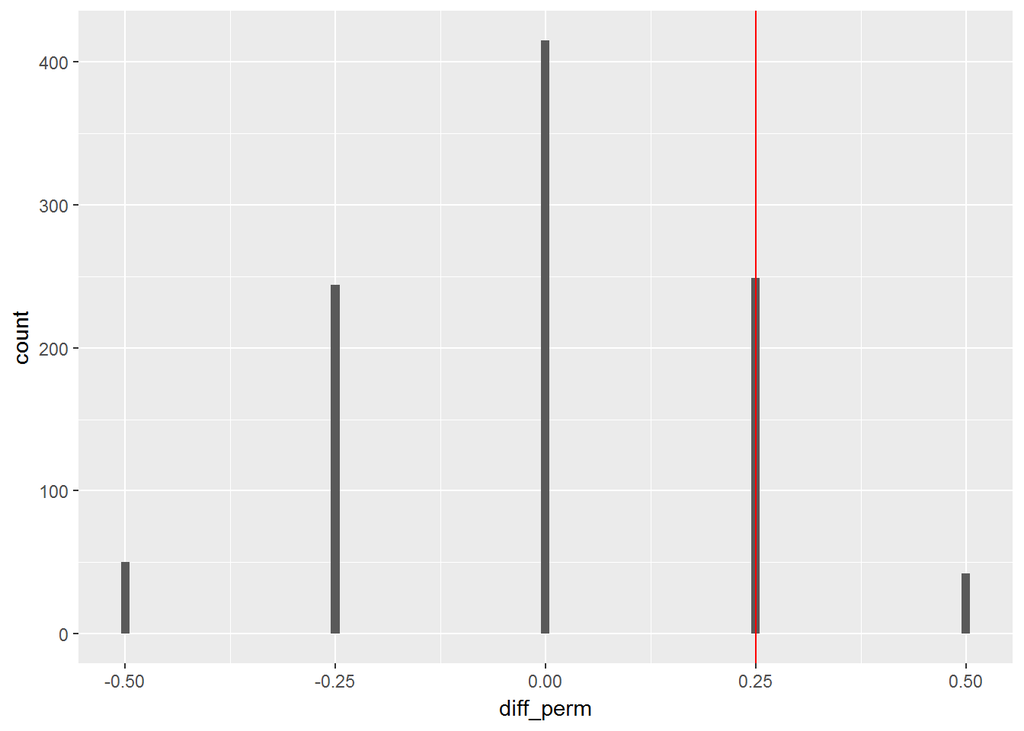

```r
# Create a 1000 permutation for each
disc_small_perm <- disc_small %>%
  oilabs_rep_sample_n(size = nrow(disc_small), reps = 1000) %>%
  mutate(prom_perm = sample(promote)) %>%
  group_by(replicate, sex) %>%
  summarize(prop_prom_perm = mean(prom_perm == "promoted"),
            prop_prom = mean(promote == "promoted")) %>%
  summarize(diff_perm = diff(prop_prom_perm),
            diff_orig = diff(prop_prom))  # male - female


# Create a 1000 permutation for each
disc_big_perm <- disc_big %>%
  oilabs_rep_sample_n(size = nrow(disc_big), reps = 1000) %>%
  mutate(prom_perm = sample(promote)) %>%
  group_by(replicate, sex) %>%
  summarize(prop_prom_perm = mean(prom_perm == "promoted"),
            prop_prom = mean(promote == "promoted")) %>%
  summarize(diff_perm = diff(prop_prom_perm),
            diff_orig = diff(prop_prom))  # male - female


# Plot the distributions of permuted differences
ggplot(disc_small_perm, aes(x = diff_perm)) +
  geom_histogram(binwidth = 0.01) +
  geom_vline(aes(xintercept = diff_orig), col = "red")
```

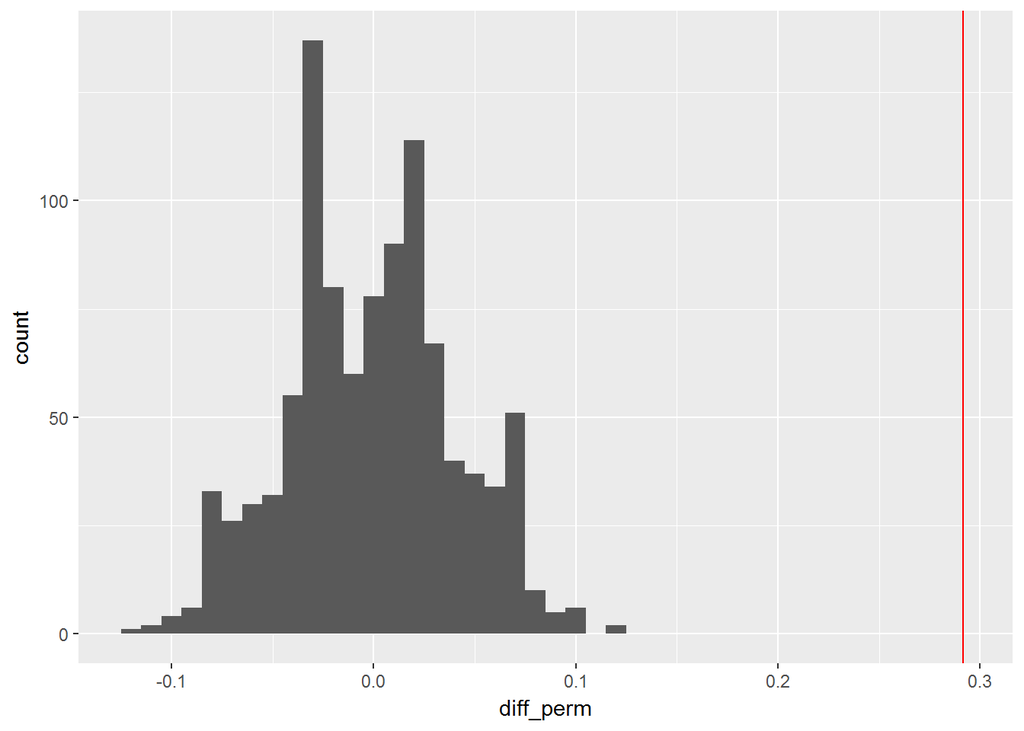

```r
ggplot(disc_big_perm, aes(x = diff_perm)) +
  geom_histogram(binwidth = 0.01) +
  geom_vline(aes(xintercept = diff_orig), col = "red")
```

```r
# Recall the quantiles associated with the original dataset
disc_perm %>%
  summarize(q.90 = quantile(diff_perm, p = 0.90),
            q.95 = quantile(diff_perm, p = 0.95),
            q.99 = quantile(diff_perm, p = 0.99)
            )
```

```
## # A tibble: 1 × 3
##        q.90      q.95      q.99
##       <dbl>     <dbl>     <dbl>
## 1 0.1333333 0.2083333 0.2916667
```

```r
# Calculate the quantiles associated with the small dataset
disc_small_perm %>%
  summarize(q.90 = quantile(diff_perm, p = 0.90),
            q.95 = quantile(diff_perm, p = 0.95),
            q.99 = quantile(diff_perm, p = 0.99)
            )
```

```
## # A tibble: 1 × 3
##    q.90  q.95  q.99
##   <dbl> <dbl> <dbl>
## 1  0.25  0.25   0.5
```

```r
# Calculate the quantiles associated with the big dataset
disc_big_perm %>%
  summarize(q.90 = quantile(diff_perm, p = 0.90),
            q.95 = quantile(diff_perm, p = 0.95),
            q.99 = quantile(diff_perm, p = 0.99)
            )
```

```
## # A tibble: 1 × 3
##         q.90       q.95       q.99
##        <dbl>      <dbl>      <dbl>
## 1 0.05833333 0.06666667 0.09166667
```

```r
# Calculate the p-value for the original dataset
disc_perm %>%
  summarize(mean(diff_orig <= diff_perm))
```

```
## # A tibble: 1 × 1
##   `mean(diff_orig <= diff_perm)`
##                            <dbl>
## 1                          0.023
```

```r
# Calculate the p-value for the small dataset
disc_small_perm %>%
  summarize(mean(diff_orig <= diff_perm))
```

```
## # A tibble: 1 × 1
##   `mean(diff_orig <= diff_perm)`
##                            <dbl>
## 1                          0.291
```

```r
# Calculate the p-value for the big dataset
disc_big_perm %>%
  summarize(mean(diff_orig <= diff_perm))
```

```
## # A tibble: 1 × 1
##   `mean(diff_orig <= diff_perm)`
##                            <dbl>
## 1                              0
```

```r
dnPromote <- "promoted ; promoted ; promoted ; promoted ; promoted ; promoted ; promoted ; promoted ; promoted ; promoted ; promoted ; promoted ; promoted ; promoted ; promoted ; promoted ; promoted ; promoted ; promoted ; promoted ; promoted ; promoted ; promoted ; promoted ; promoted ; promoted ; promoted ; promoted ; promoted ; promoted ; promoted ; promoted ; promoted ; promoted ; promoted ; not_promoted ; not_promoted ; not_promoted ; not_promoted ; not_promoted ; not_promoted ; not_promoted ; not_promoted ; not_promoted ; not_promoted ; not_promoted ; not_promoted ; not_promoted"
dnSex <- "male ; male ; male ; male ; male ; male ; male ; male ; male ; male ; male ; male ; male ; male ; male ; male ; male ; male ; female ; female ; female ; female ; female ; female ; female ; female ; female ; female ; female ; female ; female ; female ; female ; female ; female ; male ; male ; male ; male ; male ; male ; female ; female ; female ; female ; female ; female ; female"

disc_new <- data.frame(promote=factor(strsplit(dnPromote, " ; ")[[1]],
                                      levels=c("not_promoted", "promoted")
                                      ),
                       sex=factor(strsplit(dnSex, " ; ")[[1]])
                       )

# Create a 1000 permutation for each
disc_perm <- disc %>%
  oilabs_rep_sample_n(size = nrow(disc), reps = 1000) %>%
  mutate(prom_perm = sample(promote)) %>%
  group_by(replicate, sex) %>%
  summarize(prop_prom_perm = mean(prom_perm == "promoted"),
            prop_prom = mean(promote == "promoted")) %>%
  summarize(diff_perm = diff(prop_prom_perm),
            diff_orig = diff(prop_prom))  # male - female


disc_new_perm <- disc_new %>%
  oilabs_rep_sample_n(size = nrow(disc_new), reps = 1000) %>%
  mutate(prom_perm = sample(promote)) %>%
  group_by(replicate, sex) %>%
  summarize(prop_prom_perm = mean(prom_perm == "promoted"),
            prop_prom = mean(promote == "promoted")) %>%
  summarize(diff_perm = diff(prop_prom_perm),
            diff_orig = diff(prop_prom))  # male - female


# Recall the original data
disc %>%
  select(sex, promote) %>%
  table()
```

```
##         promote
## sex      not_promoted promoted
##   female           10       14
##   male              3       21
```

```r
# Tabulate the new data
disc_new %>%
  select(sex, promote) %>%
  table()
```

```
##         promote
## sex      not_promoted promoted
##   female            7       17
##   male              6       18
```

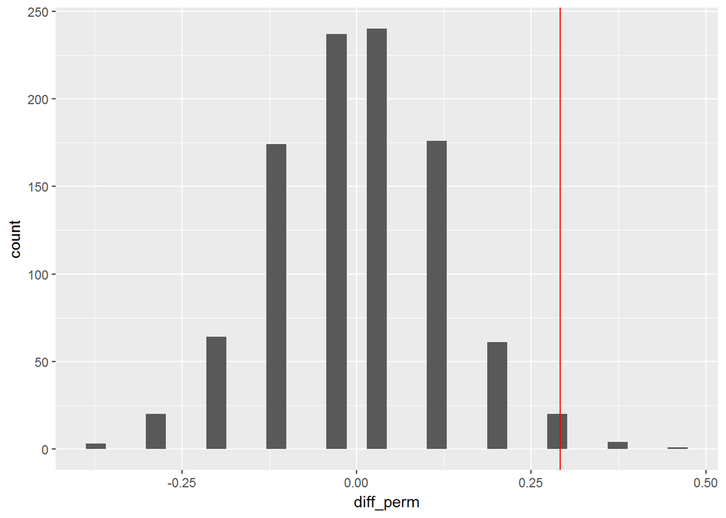

```r
# Plot the distribution of the original permuted differences
ggplot(disc_perm, aes(x = diff_perm)) +
  geom_histogram() +
  geom_vline(aes(xintercept = diff_orig), col = "red")
```

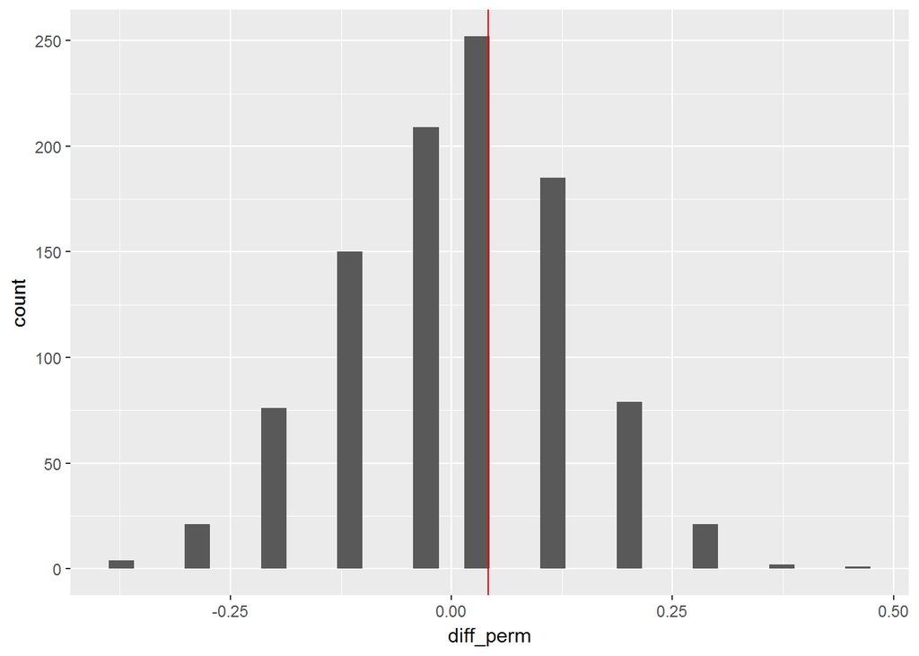

```r
# Plot the distribution of the new permuted differences
ggplot(disc_new_perm, aes(x = diff_perm)) +
  geom_histogram() +
  geom_vline(aes(xintercept = diff_orig), col = "red")
```

```r
# Find the p-value from the original data
disc_perm %>%
  summarize(mean(diff_orig <= diff_perm))
```

```
## # A tibble: 1 × 1
##   `mean(diff_orig <= diff_perm)`
##                            <dbl>
## 1                          0.025
```

```r
# Find the p-value from the new data
disc_new_perm %>%
  summarize(mean(diff_orig <= diff_perm))
```

```
## # A tibble: 1 × 1
##   `mean(diff_orig <= diff_perm)`
##                            <dbl>
## 1                           0.54
```

Chapter 3 - Hypothesis Testing Errors

Opportuinity cost - do reminders about saving money encourage students to purchase fewer DVDs? (Frederick et al study):

- Control group of 75 students - A) buy video, B) do not buy video
- Treatment group of 75 students - A) buy video, B) do not buy video, with reminder that money can be saved
- Ho: Reminder has no impact
- Ha: Reminder will reduce DVD purchasing

Errors and their consequences - consequences of various conclusions and associated errors:

- Type 1 Error - Reject a true Ho (similar to “wrongly convicted”)
- Type 2 Error - Fail to reject a false Ho

Example code includes:

```r
oppDec <- "buyDVD ; buyDVD ; buyDVD ; buyDVD ; buyDVD ; buyDVD ; buyDVD ; buyDVD ; buyDVD ; buyDVD ; buyDVD ; buyDVD ; buyDVD ; buyDVD ; buyDVD ; buyDVD ; buyDVD ; buyDVD ; buyDVD ; buyDVD ; buyDVD ; buyDVD ; buyDVD ; buyDVD ; buyDVD ; buyDVD ; buyDVD ; buyDVD ; buyDVD ; buyDVD ; buyDVD ; buyDVD ; buyDVD ; buyDVD ; buyDVD ; buyDVD ; buyDVD ; buyDVD ; buyDVD ; buyDVD ; buyDVD ; buyDVD ; buyDVD ; buyDVD ; buyDVD ; buyDVD ; buyDVD ; buyDVD ; buyDVD ; buyDVD ; buyDVD ; buyDVD ; buyDVD ; buyDVD ; buyDVD ; buyDVD ; buyDVD ; buyDVD ; buyDVD ; buyDVD ; buyDVD ; buyDVD ; buyDVD ; buyDVD ; buyDVD ; buyDVD ; buyDVD ; buyDVD ; buyDVD ; buyDVD ; buyDVD ; buyDVD ; buyDVD ; buyDVD ; buyDVD ; buyDVD ; buyDVD ; buyDVD ; buyDVD ; buyDVD ; buyDVD ; buyDVD ; buyDVD ; buyDVD ; buyDVD ; buyDVD ; buyDVD ; buyDVD ; buyDVD ; buyDVD ; buyDVD ; buyDVD ; buyDVD ; buyDVD ; buyDVD ; buyDVD ; buyDVD ; nobuyDVD ; nobuyDVD ; nobuyDVD ; nobuyDVD ; nobuyDVD ; nobuyDVD ; nobuyDVD ; nobuyDVD ; nobuyDVD ; nobuyDVD ; nobuyDVD ; nobuyDVD ; nobuyDVD ; nobuyDVD ; nobuyDVD ; nobuyDVD ; nobuyDVD ; nobuyDVD ; nobuyDVD ; nobuyDVD ; nobuyDVD ; nobuyDVD ; nobuyDVD ; nobuyDVD ; nobuyDVD ; nobuyDVD ; nobuyDVD ; nobuyDVD ; nobuyDVD ; nobuyDVD ; nobuyDVD ; nobuyDVD ; nobuyDVD ; nobuyDVD ; nobuyDVD ; nobuyDVD ; nobuyDVD ; nobuyDVD ; nobuyDVD ; nobuyDVD ; nobuyDVD ; nobuyDVD ; nobuyDVD ; nobuyDVD ; nobuyDVD ; nobuyDVD ; nobuyDVD ; nobuyDVD ; nobuyDVD ; nobuyDVD ; nobuyDVD ; nobuyDVD ; nobuyDVD"
oppGroup <- "control ; control ; control ; control ; control ; control ; control ; control ; control ; control ; control ; control ; control ; control ; control ; control ; control ; control ; control ; control ; control ; control ; control ; control ; control ; control ; control ; control ; control ; control ; control ; control ; control ; control ; control ; control ; control ; control ; control ; control ; control ; control ; control ; control ; control ; control ; control ; control ; control ; control ; control ; control ; control ; control ; control ; control ; treatment ; treatment ; treatment ; treatment ; treatment ; treatment ; treatment ; treatment ; treatment ; treatment ; treatment ; treatment ; treatment ; treatment ; treatment ; treatment ; treatment ; treatment ; treatment ; treatment ; treatment ; treatment ; treatment ; treatment ; treatment ; treatment ; treatment ; treatment ; treatment ; treatment ; treatment ; treatment ; treatment ; treatment ; treatment ; treatment ; treatment ; treatment ; treatment ; treatment ; treatment ; control ; control ; control ; control ; control ; control ; control ; control ; control ; control ; control ; control ; control ; control ; control ; control ; control ; control ; control ; treatment ; treatment ; treatment ; treatment ; treatment ; treatment ; treatment ; treatment ; treatment ; treatment ; treatment ; treatment ; treatment ; treatment ; treatment ; treatment ; treatment ; treatment ; treatment ; treatment ; treatment ; treatment ; treatment ; treatment ; treatment ; treatment ; treatment ; treatment ; treatment ; treatment ; treatment ; treatment ; treatment ; treatment"

opportunity <- data.frame(decision=factor(strsplit(oppDec, " ; ")[[1]]),
                          group=factor(strsplit(oppGroup, " ; ")[[1]])
                          )

# Tabulate the data
opportunity %>%
  select(decision, group) %>%
  table()
```

```
##           group
## decision   control treatment
##   buyDVD        56        41
##   nobuyDVD      19        34
```

```r
# Find the proportion who bought the DVD in each group
opportunity %>%
  group_by(group) %>%
  summarize(buy_prop = mean(decision == "buyDVD"))
```

```
## # A tibble: 2 × 2
##       group  buy_prop
##      <fctr>     <dbl>
## 1   control 0.7466667
## 2 treatment 0.5466667
```

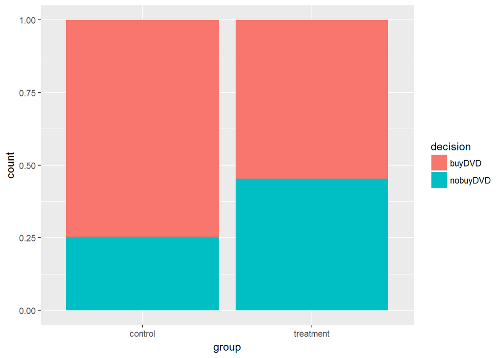

```r
# Create a barplot
ggplot(opportunity, aes(x = group, fill = decision)) +
  geom_bar(position="fill")
```

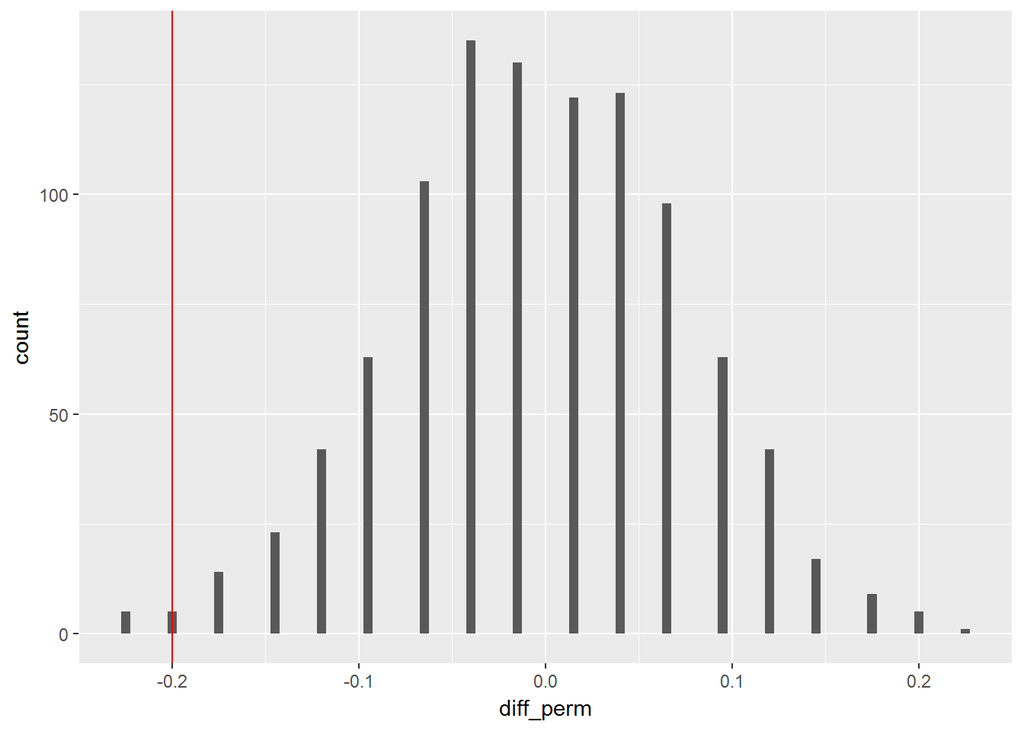

```r
# Data frame of differences in purchase rates after permuting
opp_perm <- opportunity %>%
  oilabs_rep_sample_n(size = nrow(opportunity), reps = 1000) %>%
  mutate(dec_perm = sample(decision)) %>%
  group_by(replicate, group) %>%
  summarize(prop_buy_perm = mean(dec_perm == "buyDVD"),
            prop_buy = mean(decision == "buyDVD")) %>%
  summarize(diff_perm = diff(prop_buy_perm),
            diff_orig = diff(prop_buy))  # treatment - control

# Histogram of permuted differences
ggplot(opp_perm, aes(x = diff_perm)) +
  geom_histogram(binwidth = .005) +
  geom_vline(aes(xintercept = diff_orig), col = "red")
```

```r
# Calculate the p-value
opp_perm %>%
  summarize(mean(diff_perm <= diff_orig))
```

```
## # A tibble: 1 × 1
##   `mean(diff_perm <= diff_orig)`
##                            <dbl>
## 1                           0.01
```

```r
# Calculate the two-sided p-value
opp_perm %>%
  summarize(2*mean(diff_perm <= diff_orig))
```

```
## # A tibble: 1 × 1
##   `2 * mean(diff_perm <= diff_orig)`
##                                <dbl>
## 1                               0.02
```

Chapter 4 - Confidence Intervals

Parameters and confidence intervals - research questions can be comparative (hypothesis test) or estimation (confidence intervals):

- Estimation problems should be answered with confidence intervals
- A “parameter” is a numerical value from the population
- A “confidence interval” is a range of number that hopefully captures the true parameter

Bootstrapping:

- The statistic p-hat is the proportion of success in the sample
- The parameter p is the proportion of success in the population
- With a confidence interval, there is no null population; goal is to determine how do p and p-hat vary
- Bootstrapping lets us estimate the distance from the statistic (p-hat) and population (p)
- Bootstrapping is the process of re-sampling with replacement (to the same size) from the sample; provides an excellent estimation of the population
  - The bootstrapping statistic is generally called p-hat-star
  - The variability in the bootstrapping statistic provides an excellent approximation of the population standard error

Variability in p-hat - how far are the sample data from the parameter?

- Bootstrapping provides about the same standard error (SE) as actual sampling from the population
- Roughly 95% of sample will prodce p-hats that are within 2 SE of the center

Interpreting CI and technical conditions:

- We are X% confident that the true proportion of people planning to do Y is between (X% CI)
- Technical conditions need to hold for this to work
  1. Sampling distribution of the statistic is reasonably symmetric and bell-shaped
  2. Sample size is reasonably large

Example code includes:

```r
# Do not have this dataset (30000 x 2 - poll-vote) - 30 votes in each of 1000 samples
voteSum <- c(9, 11, 12, 13, 14, 15, 16, 17, 18, 19, 20, 21, 22, 23, 24, 25)
voteN <- c(1, 7, 10, 27, 42, 90, 101, 143, 151, 136, 129, 79, 43, 25, 13, 3)

voteAll <- integer(0)
for (intCtr in seq_along(voteSum)) {
    vecTemp <- rep(0L, 30)
    vecTemp[seq_len(voteSum[intCtr])] <- 1L
    voteAll <- c(voteAll, rep(vecTemp, times=voteN[intCtr]))
}
voteNum <- sample(1:1000, 1000, replace=FALSE)

# Needs to be a tibble since oilabs_rep_sample_n() has an implied drop=TRUE for data frames
all_polls <- tibble::as_tibble(data.frame(poll=rep(voteNum, each=30),
                                          vote=voteAll
                                          ) %>% arrange(poll)
                               )


# Select one poll from which to resample: one_poll
one_poll <- all_polls %>%
  filter(poll == 1) %>%
  select(vote)

# Generate 1000 resamples of one_poll: one_poll_boot_30
one_poll_boot_30 <- one_poll %>%
  oilabs_rep_sample_n(size = nrow(one_poll), replace = TRUE, reps = 1000)

# Compute p-hat for each poll: ex1_props
ex1_props <- all_polls %>%
  group_by(poll) %>%
  summarize(prop_yes = mean(vote))

# Compute p-hat* for each resampled poll: ex2_props
ex2_props <- one_poll_boot_30 %>%
  group_by(replicate) %>%
  summarize(prop_yes = mean(vote))

# Compare variability of p-hat and p-hat*
ex1_props %>% summarize(sd(prop_yes))
```

```
## # A tibble: 1 × 1
##   `sd(prop_yes)`
##            <dbl>
## 1     0.08683128
```

```r
ex2_props %>% summarize(sd(prop_yes))
```

```
## # A tibble: 1 × 1
##   `sd(prop_yes)`
##            <dbl>
## 1     0.08874373
```

```r
# Resample from one_poll with n = 3: one_poll_boot_3
one_poll_boot_3 <- one_poll %>%
  oilabs_rep_sample_n(3, replace = TRUE, reps = 1000)

# Resample from one_poll with n = 300: one_poll_boot_300
one_poll_boot_300 <- one_poll %>%
  oilabs_rep_sample_n(300, replace = TRUE, reps = 1000)

# Compute p-hat* for each resampled poll: ex3_props
ex3_props <- one_poll_boot_3 %>%
  summarize(prop_yes = mean(vote))

# Compute p-hat* for each resampled poll: ex4_props
ex4_props <- one_poll_boot_300 %>%
  summarize(prop_yes = mean(vote))

# Compare variability of p-hat* for n = 3 vs. n = 300
ex3_props %>% summarize(sd(prop_yes))
```

```
## # A tibble: 1 × 1
##   `sd(prop_yes)`
##            <dbl>
## 1      0.2964122
```

```r
ex4_props %>% summarize(sd(prop_yes))
```

```
## # A tibble: 1 × 1
##   `sd(prop_yes)`
##            <dbl>
## 1     0.02826066
```

```r
# Recall the variability of sample proportions
ex1_props %>% summarize(sd(prop_yes))
```

```
## # A tibble: 1 × 1
##   `sd(prop_yes)`
##            <dbl>
## 1     0.08683128
```

```r
ex2_props %>% summarize(sd(prop_yes))
```

```
## # A tibble: 1 × 1
##   `sd(prop_yes)`
##            <dbl>
## 1     0.08874373
```

```r
ex3_props %>% summarize(sd(prop_yes))
```

```
## # A tibble: 1 × 1
##   `sd(prop_yes)`
##            <dbl>
## 1      0.2964122
```

```r
ex4_props %>% summarize(sd(prop_yes))
```

```
## # A tibble: 1 × 1
##   `sd(prop_yes)`
##            <dbl>
## 1     0.02826066
```

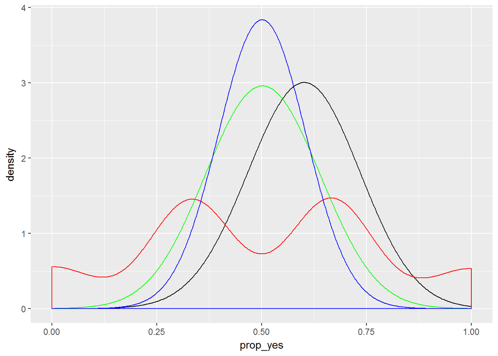

```r
# Create smoothed density curves for all four experiments
ggplot() +
  geom_density(data = ex1_props, aes(x = prop_yes), col = "black", bw = .1) +
  geom_density(data = ex2_props, aes(x = prop_yes), col = "green", bw = .1) +
  geom_density(data = ex3_props, aes(x = prop_yes), col = "red", bw = .1) +
  geom_density(data = ex4_props, aes(x = prop_yes), col = "blue", bw = .1)
```

```r
# Compute proportion of votes for Candidate X: props
props <- all_polls %>%
  group_by(poll) %>%
  summarize(prop_yes = mean(vote))

# Proportion of polls within 2SE
props %>%
  mutate(lower = mean(prop_yes) - 2 * sd(prop_yes),
         upper = mean(prop_yes) + 2 * sd(prop_yes),
         in_CI = prop_yes > lower & prop_yes < upper) %>%
  summarize(mean(in_CI))
```

```
## # A tibble: 1 × 1
##   `mean(in_CI)`
##           <dbl>
## 1         0.966
```

```r
# Again, set the one sample that was collected
one_poll <- all_polls %>%
  filter(poll == 1) %>%
  select(vote)

# Compute p-hat from one_poll: p_hat
p_hat <- mean(one_poll$vote)

# Bootstrap to find the SE of p-hat: one_poll_boot
one_poll_boot <- one_poll %>%
  oilabs_rep_sample_n(30, replace = TRUE, reps = 1000) %>%
  summarize(prop_yes_boot = mean(vote))

# Create an interval of plausible values
one_poll_boot %>%
  summarize(lower = p_hat - 2 * sd(prop_yes_boot),
            upper = p_hat + 2 * sd(prop_yes_boot)
            )
```

```
## # A tibble: 1 × 2
##       lower     upper
##       <dbl>     <dbl>
## 1 0.3138709 0.6861291
```

```r
# Find the 2.5% and 97.5% of the p-hat values
one_poll_boot %>%
  summarize(q025_prop = quantile(prop_yes_boot, p = 0.025),
            q975_prop = quantile(prop_yes_boot, p = 0.975))
```

```
## # A tibble: 1 × 2
##   q025_prop q975_prop
##       <dbl>     <dbl>
## 1 0.3333333 0.6666667
```

```r
# Bootstrap t-confidence interval for comparison
one_poll_boot %>%
  summarize(lower = p_hat - 2 * sd(prop_yes_boot),
            upper = p_hat + 2 * sd(prop_yes_boot)
            )
```

```
## # A tibble: 1 × 2
##       lower     upper
##       <dbl>     <dbl>
## 1 0.3138709 0.6861291
```

```r
# Recall the bootstrap t-confidence interval
p_hat <- mean(one_poll$vote)
one_poll_boot %>%
  summarize(lower = p_hat - 2 * sd(prop_yes_boot),
            upper = p_hat + 2 * sd(prop_yes_boot))
```

```
## # A tibble: 1 × 2
##       lower     upper
##       <dbl>     <dbl>
## 1 0.3138709 0.6861291
```

```r
# Collect a sample of 30 observations from the population
one_poll <- as.tbl(data.frame(vote = rbinom(n = 30, 1, .6)))

# Resample the data using samples of size 300 (an incorrect strategy!)
one_poll_boot_300 <- one_poll %>%
  oilabs_rep_sample_n(size=300, replace = TRUE, reps = 1000) %>%
  summarize(prop_yes_boot = mean(vote))

# Find the endpoints of the the bootstrap t-confidence interval
one_poll_boot_300 %>%
  summarize(lower = p_hat - 2 * sd(prop_yes_boot),
            upper = p_hat + 2 * sd(prop_yes_boot)
            )
```

```
## # A tibble: 1 × 2
##       lower     upper
##       <dbl>     <dbl>
## 1 0.4497326 0.5502674
```

```r
# Resample the data using samples of size 3 (an incorrect strategy!)
one_poll_boot_3 <- one_poll %>%
  oilabs_rep_sample_n(size=3, replace = TRUE, reps = 1000) %>%
  summarize(prop_yes_boot = mean(vote))

# Find the endpoints of the the bootstrap t-confidence interval
one_poll_boot_3 %>%
  summarize(lower = p_hat - 2 * sd(prop_yes_boot),
            upper = p_hat + 2 * sd(prop_yes_boot)
            )
```

```
## # A tibble: 1 × 2
##         lower   upper
##         <dbl>   <dbl>
## 1 -0.01919018 1.01919
```

```r
# Collect 30 observations from a population with true proportion of 0.8
one_poll <- as.tbl(data.frame(vote = rbinom(n = 30, size = 1, prob = 0.8)))

# Compute p-hat of new sample: p_hat
p_hat <- mean(one_poll$vote)

# Resample the 30 observations (with replacement)
one_poll_boot <- one_poll %>%
  oilabs_rep_sample_n(size=nrow(one_poll), replace = TRUE, reps = 1000) %>%
  summarize(prop_yes_boot = mean(vote))

# Calculate the bootstrap t-confidence interval
one_poll_boot %>%
  summarize(lower = p_hat - 2 * sd(prop_yes_boot),
            upper = p_hat + 2 * sd(prop_yes_boot)
            )
```

```
## # A tibble: 1 × 2
##       lower     upper
##       <dbl>     <dbl>
## 1 0.6534714 0.9465286
```

```r
# Calculate a 95% bootstrap percentile interval
one_poll_boot %>%
  summarize(q025_prop = quantile(prop_yes_boot, p = 0.025),
            q975_prop = quantile(prop_yes_boot, p = 0.975))
```

```
## # A tibble: 1 × 2
##   q025_prop q975_prop
##       <dbl>     <dbl>
## 1 0.6658333 0.9333333
```

```r
# Calculate a 99% bootstrap percentile interval
one_poll_boot %>%
  summarize(q005_prop = quantile(prop_yes_boot, p = 0.005),
            q995_prop = quantile(prop_yes_boot, p = 0.995))
```

```
## # A tibble: 1 × 2
##   q005_prop q995_prop
##       <dbl>     <dbl>
## 1 0.5666667 0.9666667
```

```r
# Calculate a 90% bootstrap percentile interval
one_poll_boot %>%
  summarize(q05_prop = quantile(prop_yes_boot, p = 0.05),
            q95_prop = quantile(prop_yes_boot, p = 0.95))
```

```
## # A tibble: 1 × 2
##    q05_prop q95_prop
##       <dbl>    <dbl>
## 1 0.6666667      0.9
```

### *Correlation and Regression*

Chapter 1 - Correlation and Regression

Modeling bivariate relationships - relationships between two variables:

- Output variable (response, dependent, y)
- Input variable (explanatory, independent, predictor, x)
- The scatterplot has been called one of the most important techniques in understanding data
- Following a geom_point() call, axes can be labeled in many ways, including by scale_x_continuous(“xTitle”) + scale_y_continuous(“yTitle”)
- The cut(breaks=n) call will discretize a continuous numerical variable
  - Can then run a geom_boxplot() off the results

Characterizing bivariate relationships:

- Form (linear, quadratic, etc.)
- Direction (positive, negative)
- Strength of relationship
- Outliers
- There will frequently be judgment calls - not an exact science

Outliers - points that do not fit with the rest of the data:

- First step is just to identify and then investigate them

Example code includes:

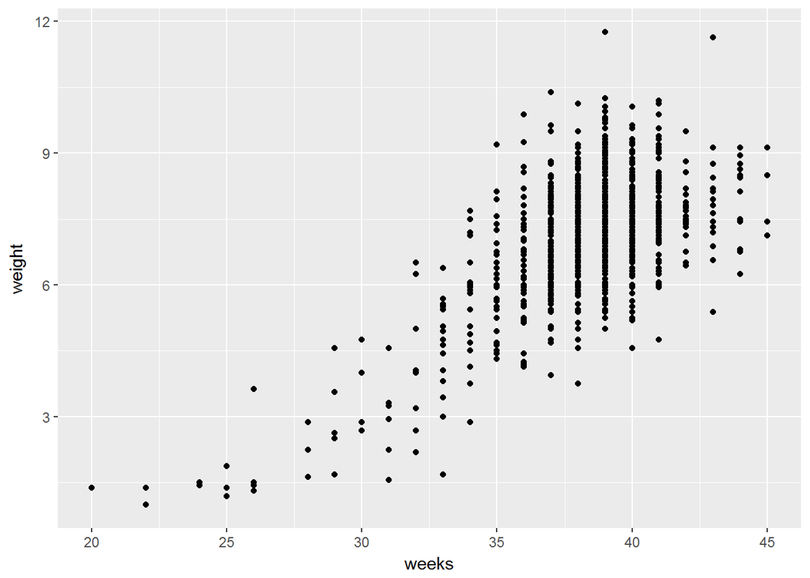

```r
data(ncbirths, package="openintro")

# Scatterplot of weight vs. weeks
ggplot(ncbirths, aes(x=weeks, y=weight)) +
  geom_point()
```

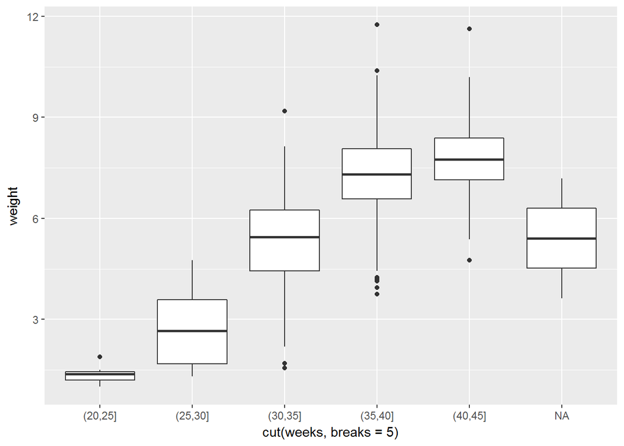

```r
# Boxplot of weight vs. weeks
ggplot(data = ncbirths,
       aes(x = cut(weeks, breaks = 5), y = weight)) +
  geom_boxplot()
```

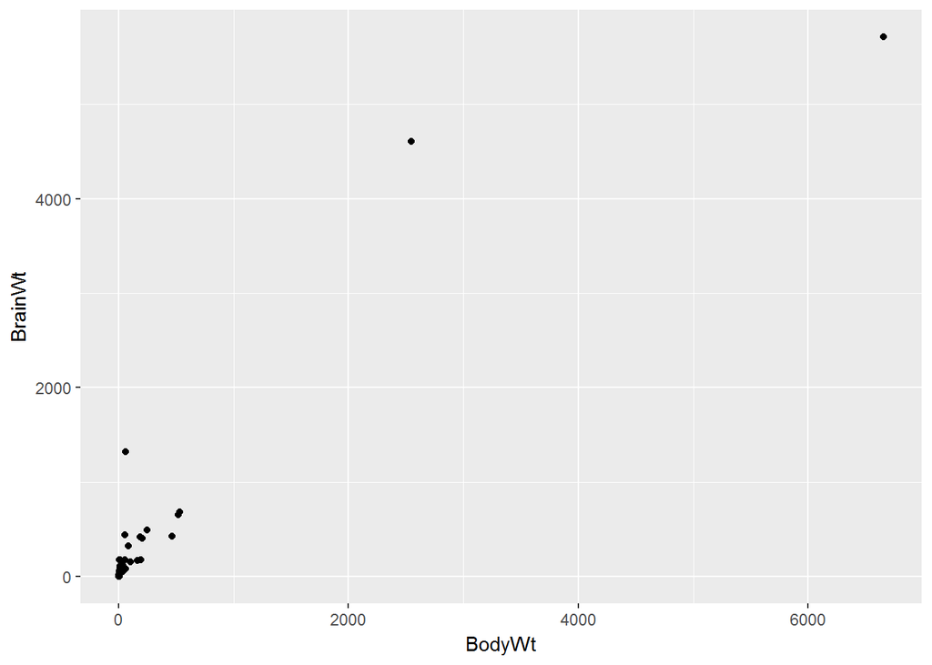

```r
# Mammals scatterplot
data(mammals, package="openintro")
ggplot(mammals, aes(x=BodyWt, y=BrainWt)) +
  geom_point()
```

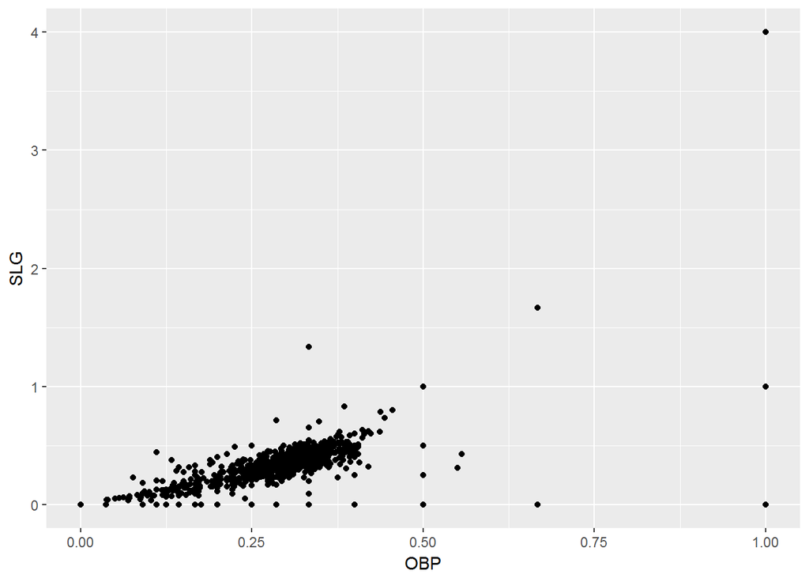

```r
# Baseball player scatterplot
data(mlbBat10, package="openintro")
ggplot(mlbBat10, aes(x=OBP, y=SLG)) +
  geom_point()
```

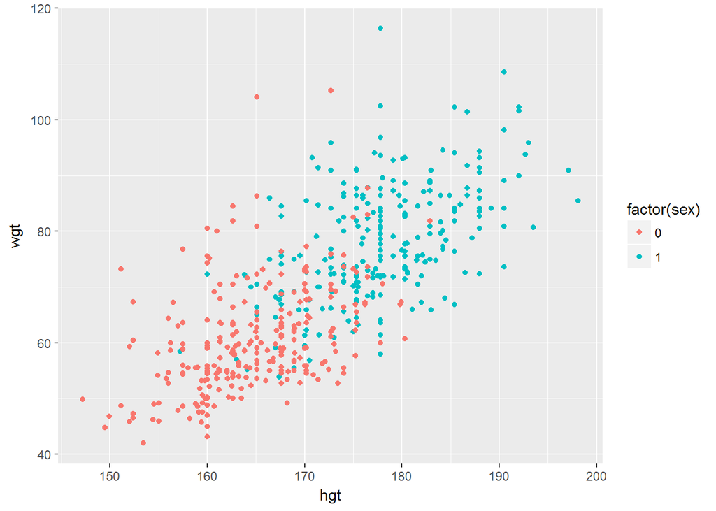

```r
# Body dimensions scatterplot
data(bdims, package="openintro")
ggplot(bdims, aes(x=hgt, y=wgt, color=factor(sex))) +
  geom_point()
```

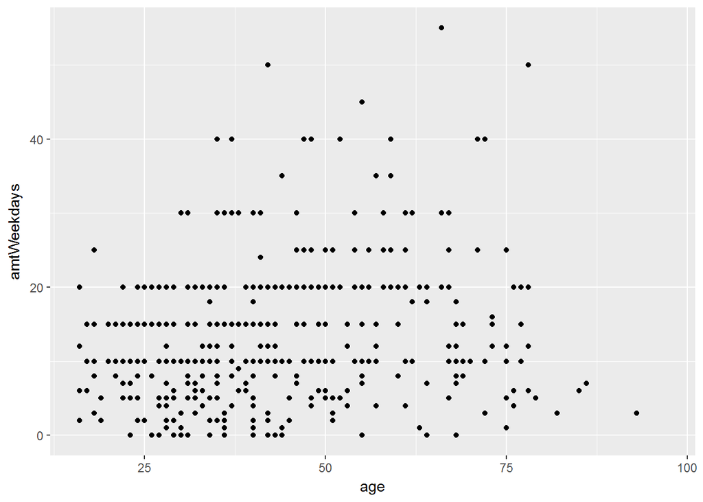

```r
# Smoking scatterplot
data(smoking, package="openintro")
ggplot(smoking, aes(x=age, y=amtWeekdays)) +
  geom_point()
```

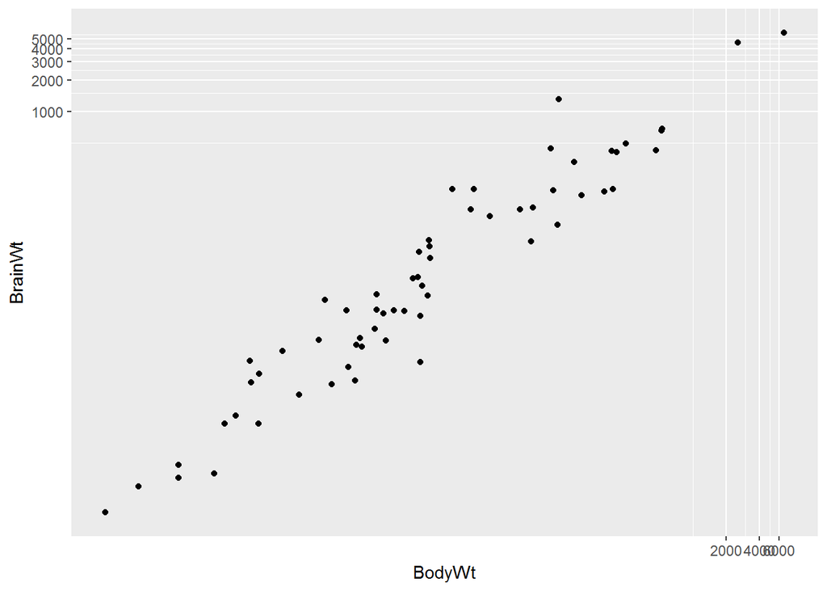

```r
# Scatterplot with coord_trans()
ggplot(data = mammals, aes(x = BodyWt, y = BrainWt)) +
  geom_point() +
  coord_trans(x = "log10", y = "log10")
```

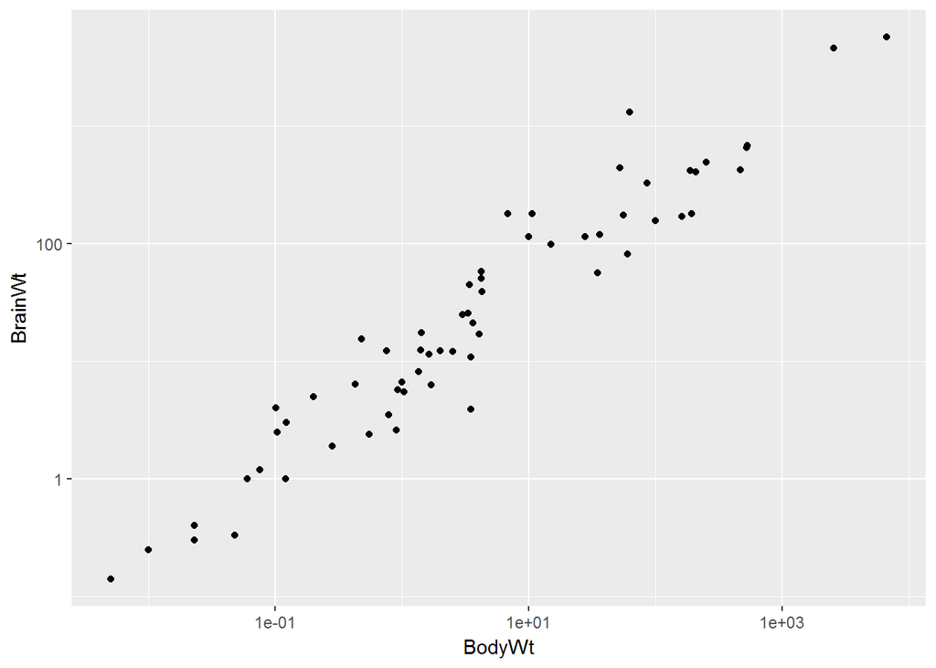

```r
# Scatterplot with scale_x_log10() and scale_y_log10()
ggplot(data = mammals, aes(x = BodyWt, y = BrainWt)) +
  geom_point() +
  scale_x_log10() + scale_y_log10()
```

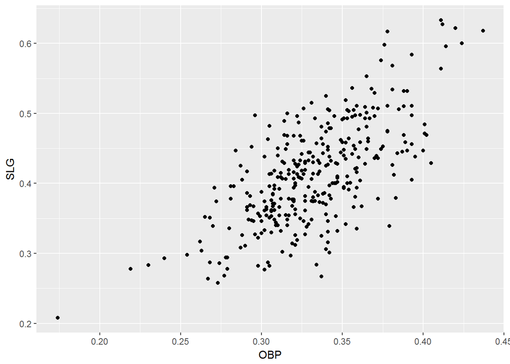

```r
# Scatterplot of SLG vs. OBP
mlbBat10 %>%
  filter(AB >= 200) %>%
  ggplot(aes(x = OBP, y = SLG)) +
  geom_point()
```

```r
# Identify the outlying player
mlbBat10 %>%
  filter(AB >= 200, OBP < 0.2)
```

```
##     name team position  G  AB  R  H 2B 3B HR RBI TB BB SO SB CS   OBP
## 1 B Wood  LAA       3B 81 226 20 33  2  0  4  14 47  6 71  1  0 0.174
##     SLG   AVG
## 1 0.208 0.146
```

Chapter 2 - Correlation

Quantifying strength of bivariate relationship - correlation:

- Sign for direction, magnitude (0-1) for strength
- Correlation measures only the linear relationship - could be very strong non-linear relationships with r=0
- “Correlation” typically means the Pearson product-moment correlation

Anscombe dataset - synthetic datasets of the problems with correlation (and regression):

- Can have the same number of points, mean/sd of both x/y, and thus correlations and regression coefficients, even with very different underlying data

Interpretation of correlation - correlation is not causality:

- Best to note that associations were observed, but without attributing causality to the findings
- Can assess serial auto-correlation (is the value of something this time period associated to its value in previous time periods)
- Correlation matrices can show many correlations all at once

Spurious correlation:

- Confounders like “large cities have high population (and thus everything associated with high population)”
- Always be on the lookout for spurious correlations

Example code includes:

```r
data(ncbirths, package="openintro")

# Compute correlation
ncbirths %>%
  summarize(N = n(), r = cor(weight, mage))
```

```
##      N          r
## 1 1000 0.05506589
```

```r
# Compute correlation for all non-missing pairs
ncbirths %>%
  summarize(N = n(), r = cor(weight, weeks, use = "pairwise.complete.obs"))
```

```
##      N         r
## 1 1000 0.6701013
```

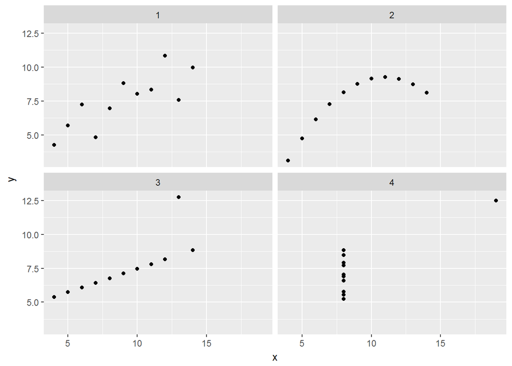

```r
data(anscombe)

Anscombe <- data.frame(x=as.vector(as.matrix(anscombe[,1:4])),
                       y=as.vector(as.matrix(anscombe[,5:8])),
                       id=rep(1:11, times=4),
                       set=rep(1:4, each=11)
                       )

ggplot(data = Anscombe, aes(x = x, y = y)) +
  geom_point() +
  facet_wrap(~ set)
```

```r
# Compute properties of Anscombe
Anscombe %>%
  group_by(set) %>%
  summarize(N = n(), mean(x), sd(x), mean(y), sd(y), cor(x, y))
```

```
## # A tibble: 4 × 7
##     set     N `mean(x)`  `sd(x)` `mean(y)`  `sd(y)` `cor(x, y)`
##   <int> <int>     <dbl>    <dbl>     <dbl>    <dbl>       <dbl>
## 1     1    11         9 3.316625  7.500909 2.031568   0.8164205
## 2     2    11         9 3.316625  7.500909 2.031657   0.8162365
## 3     3    11         9 3.316625  7.500000 2.030424   0.8162867
## 4     4    11         9 3.316625  7.500909 2.030579   0.8165214
```

```r
data(mlbBat10, package="openintro")
data(mammals, package="openintro")
data(bdims, package="openintro")


# Correlation for all baseball players
mlbBat10 %>%
  summarize(N = n(), r = cor(OBP, SLG))
```

```
##      N         r
## 1 1199 0.8145628
```

```r
# Correlation for all players with at least 200 ABs
mlbBat10 %>%
  filter(AB >= 200) %>%
  summarize(N = n(), r = cor(OBP, SLG))
```

```
##     N         r
## 1 329 0.6855364
```

```r
# Correlation of body dimensions
bdims %>%
  group_by(sex) %>%
  summarize(N = n(), r = cor(hgt, wgt))
```

```
## # A tibble: 2 × 3
##     sex     N         r
##   <int> <int>     <dbl>
## 1     0   260 0.4310593
## 2     1   247 0.5347418
```

```r
# Correlation among mammals, with and without log
mammals %>%
  summarize(N = n(),
            r = cor(BodyWt, BrainWt),
            r_log = cor(log(BodyWt), log(BrainWt)))
```

```
##    N         r     r_log
## 1 62 0.9341638 0.9595748
```

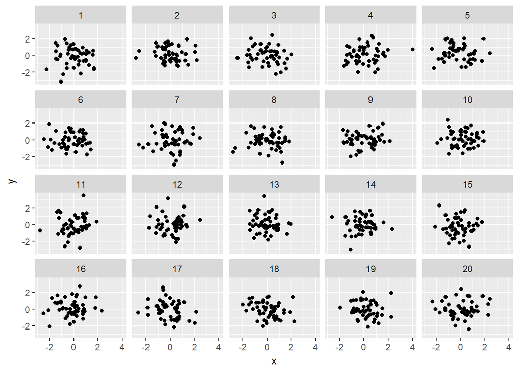

```r
# Create a random noise dataset
noise <- data.frame(x=rnorm(1000), y=rnorm(1000), z=rep(1:20, each=50))

# Create faceted scatterplot
noise %>%
  ggplot(aes(x=x, y=y)) +
  geom_point() +
  facet_wrap(~ z)
```

```r
# Compute correlations for each dataset
noise_summary <- noise %>%
  group_by(z) %>%
  summarize(N = n(), spurious_cor = cor(x, y))

# Isolate sets with correlations above 0.2 in absolute strength
noise_summary %>%
  filter(abs(spurious_cor) > 0.2)
```

```
## # A tibble: 2 × 3
##       z     N spurious_cor
##   <int> <int>        <dbl>
## 1    17    50   -0.2418963
## 2    18    50   -0.2696328
```

Chapter 3 - Simple Linear Regression

Visualization of linear models - adjusting the intercept and the slope to best fit the data:

- Criteria for judging “goodness of fit” - minimize the sum-squared distance to the line
- The best-fit line is called the “least squares” line

Understanding the linear model: Response = f(Explanatory) + Noise:

- Statisticians try to model (or account for) the Noise, often with the assumption that Noise ~ N(0, sigma-noise)
- Y is generally the actual data, while Y-hat is the expected value based on the model; Y = Y-hat + Noise
- The residuals are defined as e = Y - Y-hat (e being noise, is an estimate of the true quantity epsilon)
- Goal is to find Beta-hat that will minimize the sum-squared of epsilons
- Properties of the least-squares lines include
  - Residuals sum to zero
  - Line passes through the point that contains mean-x and mean-y
- Additional key concepts include
  - Y-hat is the expected value (best guess for the true value of Y) given the corresponding value of X
  - Beta-hats are estimates of the true, unknown betas
  - Residuals are estimates of the true, unknown epsilons

Regression vs. regression to the mean (Galton):

- Do tall parents tend to have tall children? Generally yes, although the kids are closer to the mean
- Rare for MVP player to have MVP kids, or for top musician to have top musician kids, etc.
  - Likely that kids of MVP player will be good at sports (much better than average), but not as good as parent (not MVP or even professional)

Example code includes:

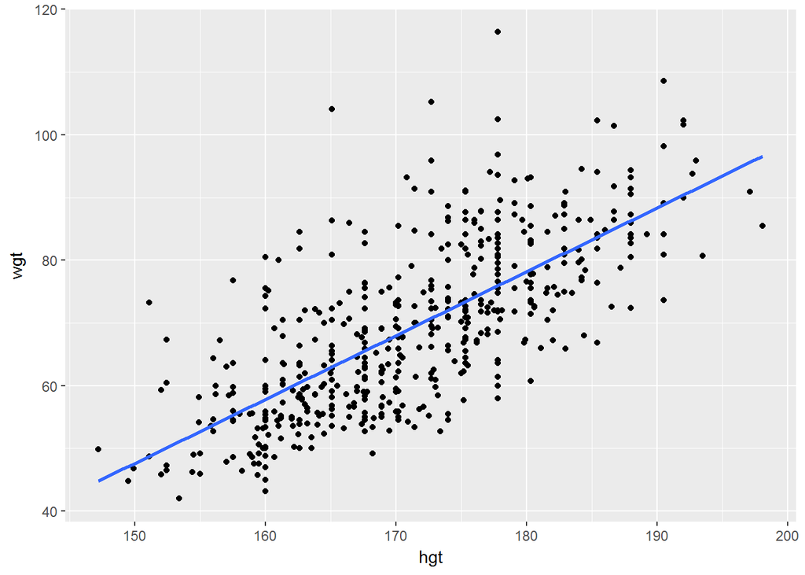

```r
# Scatterplot with regression line
ggplot(data = bdims, aes(x = hgt, y = wgt)) +
  geom_point() +
  geom_smooth(method = "lm", se = FALSE)
```

```r
bdims_summary <- bdims %>%
    summarize(N=n(), r=cor(hgt, wgt),
              mean_hgt=mean(hgt), sd_hgt=sd(hgt),
              mean_wgt=mean(wgt), sd_wgt=sd(wgt)
              )

# Print bdims_summary
bdims_summary
```

```
##     N         r mean_hgt   sd_hgt mean_wgt   sd_wgt
## 1 507 0.7173011 171.1438 9.407205 69.14753 13.34576
```

```r
# Add slope and intercept
bdims_summary %>%
  mutate(slope = r * sd_wgt / sd_hgt,
         intercept = mean_wgt - slope*mean_hgt
         )
```

```
##     N         r mean_hgt   sd_hgt mean_wgt   sd_wgt    slope intercept
## 1 507 0.7173011 171.1438 9.407205 69.14753 13.34576 1.017617 -105.0113
```

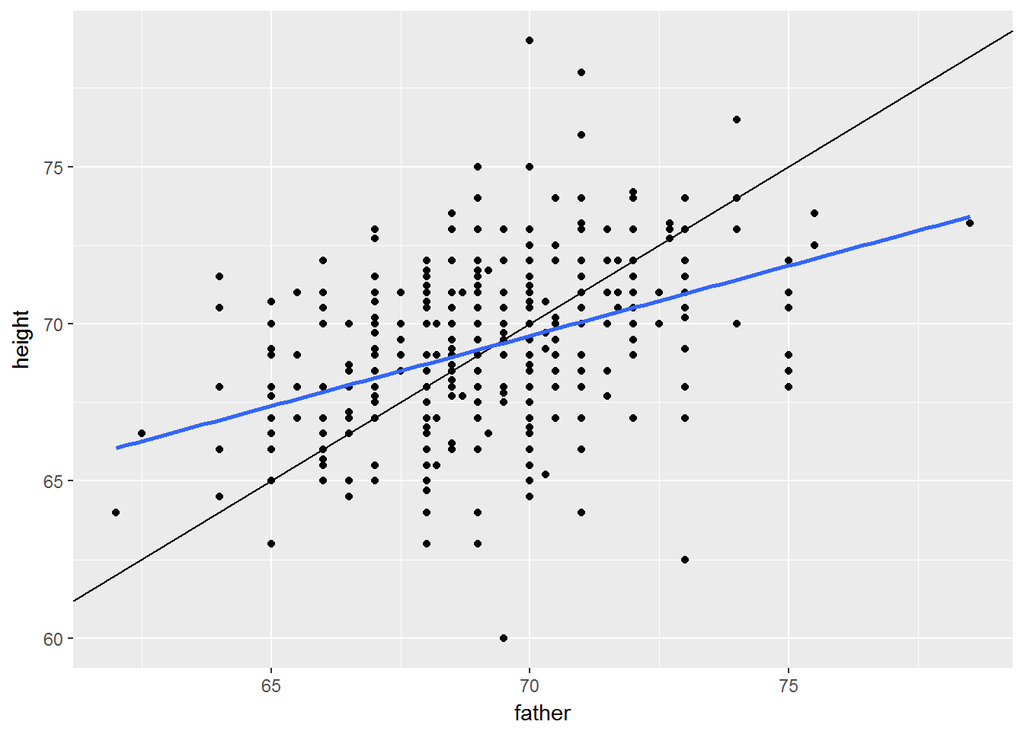

```r
data(GaltonFamilies, package="HistData")


GaltonUse <- GaltonFamilies %>%
    mutate(sex=gender, height=childHeight) %>%
    select(family, father, mother, sex, height)
GaltonUse <- GaltonUse %>%
    left_join(GaltonUse %>% group_by(family) %>% summarize(nkids=n()), by="family")

Galton_women <- GaltonUse %>%
    filter(sex=="female")
Galton_men <- GaltonUse %>%
    filter(sex=="male")


# Height of children vs. height of father
ggplot(data = Galton_men, aes(x = father, y = height)) +
  geom_point() +
  geom_abline(slope = 1, intercept = 0) +
  geom_smooth(method = "lm", se = FALSE)
```

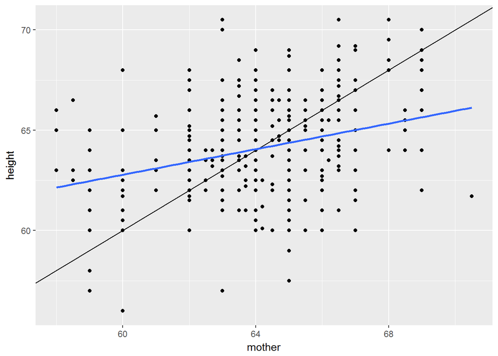

```r
# Height of children vs. height of mother
ggplot(data = Galton_women, aes(x = mother, y = height)) +
  geom_point() +
  geom_abline(slope = 1, intercept = 0) +
  geom_smooth(method = "lm", se = FALSE)
```

Chapter 4 - Interpreting Regression Models

Interpretation of regression coefficients - UCLA textbook pricing (dataset ‘textbooks’):

- Amazon pricing vs UCLA pricing for textbooks - lm(uclaNew ~ amazNew, data=textbooks)
- Extrapolation to values outside the data range is especially dangerous

Linear model object interpretation:

- Can save the lm results in to an object with class “lm”, and can get general descriptive statistics
  - The straight print command for an lm will return the call and the coefficients
  - coef(lmObj) will return just the coefficients
  - summary(lmObj) will return data that is valuable for inferences
- The fitted.values(lmObj) will return the y-hat associated with all the x in the raw data
  - Caution that due to NA removal, length(fitted.values(lmObj)) may be different than the raw data
- The residuals(lmObj) will return the residuals (y minus y-hat) for the model
- The “tidyverse” includes broom::augment(lmObj) which creates a frame with data, fitted, se-fitted, residuals, hat, sigma, and cooks-distance

Using the linear model - residuals can give information about biggest outliers (often interesting):

- predict(lmObj, newdata=otherDF) # otherDF must be a data frame with the same variable names as the original regression
- Alternately, broom::augment(lmObj, newdata=otherDF)

Example code includes:

```r
# Linear model for weight as a function of height
lm(wgt ~ hgt, data = bdims)
```

```
##
## Call:
## lm(formula = wgt ~ hgt, data = bdims)
##
## Coefficients:
## (Intercept)          hgt
##    -105.011        1.018
```

```r
# Linear model for SLG as a function of OBP
lm(SLG ~ OBP, data=mlbBat10)
```

```
##
## Call:
## lm(formula = SLG ~ OBP, data = mlbBat10)
##
## Coefficients:
## (Intercept)          OBP
##    0.009407     1.110323
```

```r
# Log-linear model for body weight as a function of brain weight
lm(log(BodyWt) ~ log(BrainWt), data=mammals)
```

```
##
## Call:
## lm(formula = log(BodyWt) ~ log(BrainWt), data = mammals)
##
## Coefficients:
##  (Intercept)  log(BrainWt)
##       -2.509         1.225
```

```r
mod <- lm(wgt ~ hgt, data = bdims)

# Show the coefficients
coef(mod)
```

```
## (Intercept)         hgt
## -105.011254    1.017617
```

```r
# Show the full output
summary(mod)
```

```
##
## Call:
## lm(formula = wgt ~ hgt, data = bdims)
##
## Residuals:
##     Min      1Q  Median      3Q     Max
## -18.743  -6.402  -1.231   5.059  41.103
##
## Coefficients:
##               Estimate Std. Error t value Pr(>|t|)
## (Intercept) -105.01125    7.53941  -13.93   <2e-16 ***
## hgt            1.01762    0.04399   23.14   <2e-16 ***
## ---
## Signif. codes:  0 '***' 0.001 '**' 0.01 '*' 0.05 '.' 0.1 ' ' 1
##
## Residual standard error: 9.308 on 505 degrees of freedom
## Multiple R-squared:  0.5145, Adjusted R-squared:  0.5136
## F-statistic: 535.2 on 1 and 505 DF,  p-value: < 2.2e-16
```

```r
# Mean of weights equal to mean of fitted values?
mean(bdims$wgt) == mean(fitted.values(mod))
```

```
## [1] TRUE
```

```r
# Mean of the residuals
mean(residuals(mod))
```

```
## [1] -1.266971e-15
```

```r
# Create bdims_tidy
bdims_tidy <- broom::augment(mod)

# Glimpse the resulting data frame
glimpse(bdims_tidy)
```

```
## Observations: 507
## Variables: 9
## $ wgt        <dbl> 65.6, 71.8, 80.7, 72.6, 78.8, 74.8, 86.4, 78.4, 62....
## $ hgt        <dbl> 174.0, 175.3, 193.5, 186.5, 187.2, 181.5, 184.0, 18...
## $ .fitted    <dbl> 72.05406, 73.37697, 91.89759, 84.77427, 85.48661, 7...
## $ .se.fit    <dbl> 0.4320546, 0.4520060, 1.0667332, 0.7919264, 0.81834...
## $ .resid     <dbl> -6.4540648, -1.5769666, -11.1975919, -12.1742745, -...
## $ .hat       <dbl> 0.002154570, 0.002358152, 0.013133942, 0.007238576,...
## $ .sigma     <dbl> 9.312824, 9.317005, 9.303732, 9.301360, 9.312471, 9...
## $ .cooksd    <dbl> 5.201807e-04, 3.400330e-05, 9.758463e-03, 6.282074e...
## $ .std.resid <dbl> -0.69413418, -0.16961994, -1.21098084, -1.31269063,...
```

```r
ben <- data.frame(wgt=74.8, hgt=182.8)

# Print ben
ben
```

```
##    wgt   hgt
## 1 74.8 182.8
```

```r
# Predict the weight of ben
predict(mod, newdata=ben)
```

```
##        1
## 81.00909
```

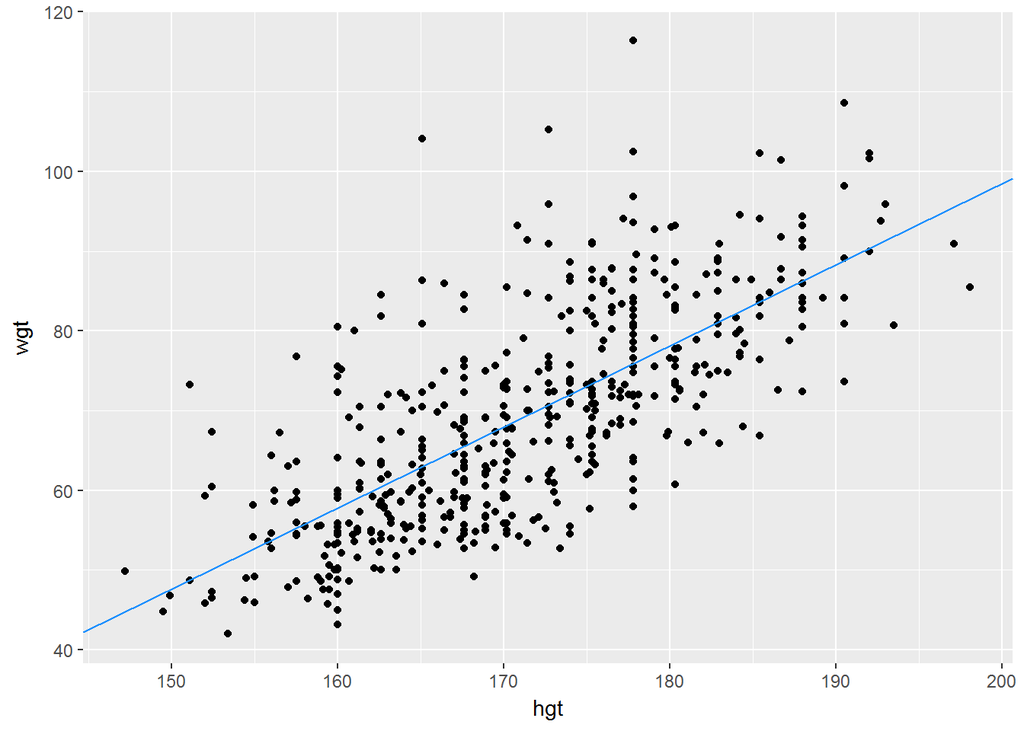

```r
# Add the line to the scatterplot
ggplot(data = bdims, aes(x = hgt, y = wgt)) +
  geom_point() +
  geom_abline(data = as.data.frame(t(coef(mod))),
              aes(intercept = `(Intercept)`, slope = hgt),
              color = "dodgerblue")
```

Chapter 5 - Model Fit

Assessing model fit - how well does the regression line fit the underlying data?

Comparing model fits:

- Benchmark is the difference from the mean-y (model where y-hat = y-bar, often known as the “null model”)
  - SST is the “total sum of squares”, or the average error associated with the null model
- R-squared is defined as 1 - SSE/SST, which is the amount of the variance explained by our model
- For simple linear regression with a single variable, R^2 is simply r^2 (correlation squared)
- R-squared should not be used as the be-all, end-all (high r-squared can be an overfit, while low r-squared can have statistically significant coefficient)
  - George Box - “all models are wrong, but some models are useful”

Unusual points - leverage and influence:

- Leverage is entirely defined by the value of the explanatory variable and the mean of the explanatory variable
  - These can be retrieved with the .hat variable in the frame created by broom::augment()
- Influence is driven by both high-leverage and also high-outlier
  - Cooks distance can be retrieved using the .cooksd variable in the frame created by broom::augment()

Dealing with unusual points - managing the impacts of leverage and influence:

- The primary technique for managing the unusual points (outliers) is to delete them
- The analysis should explore the impact of having deleted the outliers
  - The justification for removing outliers must be much better than “makes my model work better”
  - Improper deletion of outliers is intellectually dishonest and a frequent source of retracted results
- Outlier removal can further change the scope of the inferences; if only rich countries were included, the inferences only apply to the rich countries

Example code includes:

```r
mod <- lm(wgt ~ hgt, data = bdims)

# View summary of model
summary(mod)
```

```
##
## Call:
## lm(formula = wgt ~ hgt, data = bdims)
##
## Residuals:
##     Min      1Q  Median      3Q     Max
## -18.743  -6.402  -1.231   5.059  41.103
##
## Coefficients:
##               Estimate Std. Error t value Pr(>|t|)
## (Intercept) -105.01125    7.53941  -13.93   <2e-16 ***
## hgt            1.01762    0.04399   23.14   <2e-16 ***
## ---
## Signif. codes:  0 '***' 0.001 '**' 0.01 '*' 0.05 '.' 0.1 ' ' 1
##
## Residual standard error: 9.308 on 505 degrees of freedom
## Multiple R-squared:  0.5145, Adjusted R-squared:  0.5136
## F-statistic: 535.2 on 1 and 505 DF,  p-value: < 2.2e-16
```

```r
# Compute the mean of the residuals
mean(residuals(mod))
```

```
## [1] -1.266971e-15
```

```r
# Compute RMSE
sqrt(sum(residuals(mod)^2) / df.residual(mod))
```

```
## [1] 9.30804
```

```r
# View model summary
summary(mod)
```

```
##
## Call:
## lm(formula = wgt ~ hgt, data = bdims)
##
## Residuals:
##     Min      1Q  Median      3Q     Max
## -18.743  -6.402  -1.231   5.059  41.103
##
## Coefficients:
##               Estimate Std. Error t value Pr(>|t|)
## (Intercept) -105.01125    7.53941  -13.93   <2e-16 ***
## hgt            1.01762    0.04399   23.14   <2e-16 ***
## ---
## Signif. codes:  0 '***' 0.001 '**' 0.01 '*' 0.05 '.' 0.1 ' ' 1
##
## Residual standard error: 9.308 on 505 degrees of freedom
## Multiple R-squared:  0.5145, Adjusted R-squared:  0.5136
## F-statistic: 535.2 on 1 and 505 DF,  p-value: < 2.2e-16
```

```r
bdims_tidy <- broom::augment(mod)

# Compute R-squared
bdims_tidy %>%
  summarize(var_y = var(wgt), var_e = var(.resid)) %>%
  mutate(R_squared = 1 - var_e/var_y)
```

```
##      var_y    var_e R_squared
## 1 178.1094 86.46839 0.5145208
```

```r
mod <- lm(SLG ~ OBP, data=filter(mlbBat10, AB >= 10))

# Rank points of high leverage
mod %>%
  broom::augment() %>%
  arrange(desc(.hat)) %>%
  head()
```

```
##     SLG   OBP     .fitted     .se.fit      .resid       .hat     .sigma
## 1 0.000 0.000 -0.03744579 0.009956861  0.03744579 0.01939493 0.07153050
## 2 0.000 0.000 -0.03744579 0.009956861  0.03744579 0.01939493 0.07153050
## 3 0.000 0.000 -0.03744579 0.009956861  0.03744579 0.01939493 0.07153050
## 4 0.308 0.550  0.69049108 0.009158810 -0.38249108 0.01641049 0.07011360
## 5 0.000 0.037  0.01152451 0.008770891 -0.01152451 0.01504981 0.07154283
## 6 0.038 0.038  0.01284803 0.008739031  0.02515197 0.01494067 0.07153800
##        .cooksd .std.resid
## 1 0.0027664282  0.5289049
## 2 0.0027664282  0.5289049
## 3 0.0027664282  0.5289049
## 4 0.2427446800 -5.3943121
## 5 0.0002015398 -0.1624191
## 6 0.0009528017  0.3544561
```

```r
# Rank influential points
mod %>%
  broom::augment() %>%
  arrange(desc(.cooksd)) %>%
  head()
```

```
##     SLG   OBP    .fitted     .se.fit     .resid        .hat     .sigma
## 1 0.308 0.550 0.69049108 0.009158810 -0.3824911 0.016410487 0.07011360
## 2 0.833 0.385 0.47211002 0.004190644  0.3608900 0.003435619 0.07028875
## 3 0.800 0.455 0.56475653 0.006186785  0.2352435 0.007488132 0.07101125
## 4 0.379 0.133 0.13858258 0.005792344  0.2404174 0.006563752 0.07098798
## 5 0.786 0.438 0.54225666 0.005678026  0.2437433 0.006307223 0.07097257
## 6 0.231 0.077 0.06446537 0.007506974  0.1665346 0.011024863 0.07127661
##      .cooksd .std.resid
## 1 0.24274468  -5.394312
## 2 0.04407145   5.056428
## 3 0.04114818   3.302718
## 4 0.03760256   3.373787
## 5 0.03712042   3.420018
## 6 0.03057912   2.342252
```

```r
# Create nontrivial_players
nontrivial_players <- filter(mlbBat10, AB >= 10 & OBP < 0.5)

# Fit model to new data
mod_cleaner <- lm(SLG ~ OBP, data=nontrivial_players)

# View model summary
summary(mod_cleaner)
```

```
##
## Call:
## lm(formula = SLG ~ OBP, data = nontrivial_players)
##
## Residuals:
##      Min       1Q   Median       3Q      Max
## -0.31383 -0.04165 -0.00261  0.03992  0.35819
##
## Coefficients:
##              Estimate Std. Error t value Pr(>|t|)
## (Intercept) -0.043326   0.009823  -4.411 1.18e-05 ***
## OBP          1.345816   0.033012  40.768  < 2e-16 ***
## ---
## Signif. codes:  0 '***' 0.001 '**' 0.01 '*' 0.05 '.' 0.1 ' ' 1
##
## Residual standard error: 0.07011 on 734 degrees of freedom
## Multiple R-squared:  0.6937, Adjusted R-squared:  0.6932
## F-statistic:  1662 on 1 and 734 DF,  p-value: < 2.2e-16
```

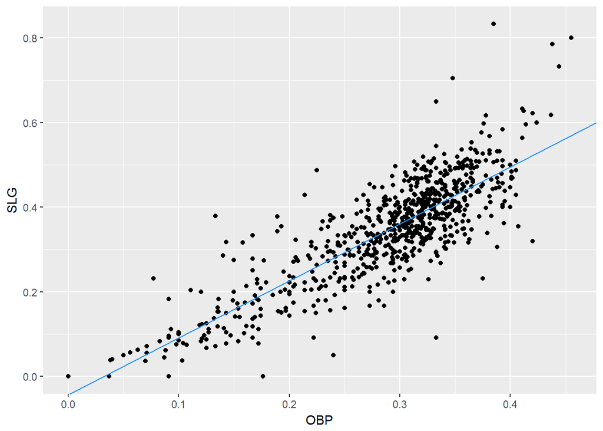

```r
# Visualize new model
ggplot(nontrivial_players, aes(x=OBP, y=SLG)) +
  geom_point() +
  geom_abline(data = as.data.frame(t(coef(mod_cleaner))),
              aes(intercept = `(Intercept)`, slope = OBP),
              color = "dodgerblue")
```

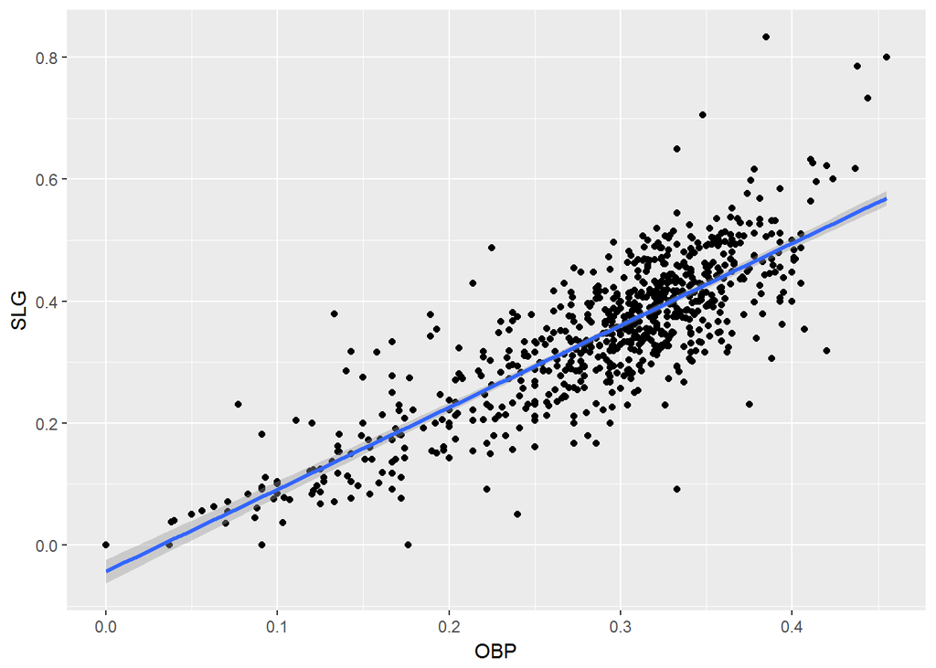

```r
# Visualize new model
ggplot(nontrivial_players, aes(x=OBP, y=SLG)) +
  geom_point() +
  geom_smooth(method="lm")
```

```r
# Rank high leverage points
mod %>%
  broom::augment() %>%
  arrange(desc(.hat), .cooksd) %>%
  head()
```

```
##     SLG   OBP     .fitted     .se.fit      .resid       .hat     .sigma
## 1 0.000 0.000 -0.03744579 0.009956861  0.03744579 0.01939493 0.07153050
## 2 0.000 0.000 -0.03744579 0.009956861  0.03744579 0.01939493 0.07153050
## 3 0.000 0.000 -0.03744579 0.009956861  0.03744579 0.01939493 0.07153050
## 4 0.308 0.550  0.69049108 0.009158810 -0.38249108 0.01641049 0.07011360
## 5 0.000 0.037  0.01152451 0.008770891 -0.01152451 0.01504981 0.07154283
## 6 0.038 0.038  0.01284803 0.008739031  0.02515197 0.01494067 0.07153800
##        .cooksd .std.resid
## 1 0.0027664282  0.5289049
## 2 0.0027664282  0.5289049
## 3 0.0027664282  0.5289049
## 4 0.2427446800 -5.3943121
## 5 0.0002015398 -0.1624191
## 6 0.0009528017  0.3544561
```